## Tuberculosis

Upload needed packages

```r
# install.packages("gmodels")
library(gmodels)
# install.packages("caTools")
library(caTools)

# install.packages("MASS")
library(MASS)

# install.packages("glmnet")
library(glmnet)
# install.packages("randomForest")
library(randomForest)
# install.packages("e1071")
library(e1071)

# install.packages("pROC")
library(pROC)
# install.packages("mice")
library(mice)
```

Upload dataset

```r
TB <- read.csv("D:\\HST936 Global Health Informatics\\Project\\Data\\full_Published Cases with Imaging_20180228.csv", header = TRUE)
```

Remove duplicate entries from the same patient

```r
# Database dimensions
dim(TB)
```

```
## [1] 683 159
```

```r
# Remove duplicate entries from the same patient
TB <- TB[!duplicated(TB$patient_id), ]

# Database dimensions
dim(TB)
```

```
## [1] 683 159
```

Outcome: Treatment failure

```r
# Treatment failure
TB$trtfailure[TB$outcome == "completed" | TB$outcome == "cured" | TB$outcome == "still_on_treatment"] <- 0
TB$trtfailure[TB$outcome == "failure" | TB$outcome == "death" | TB$outcome == "default" | TB$outcome == "died"] <- 1
TB$trtfailure <- as.factor(TB$trtfailure)

# Eliminate patients with NAs in the outcome (TB$outcome unknown or not reported)
TB <- TB[!(is.na(TB$trtfailure) == TRUE), ]

#Distribution of treatment failure
CrossTable(TB$trtfailure)
```

```
##
##
##    Cell Contents
## |-------------------------|
## |                       N |
## |         N / Table Total |
## |-------------------------|
##
##
## Total Observations in Table:  643
##
##
##           |         0 |         1 |
##           |-----------|-----------|
##           |       491 |       152 |
##           |     0.764 |     0.236 |
##           |-----------|-----------|
##
##
##
##
```

Predictors

```r
# Country
CrossTable(TB$country)
```

```
##
##
##    Cell Contents
## |-------------------------|
## |                       N |
## |         N / Table Total |
## |-------------------------|
##
##
## Total Observations in Table:  643
##
##
##            | azerbaijan |    belarus |    georgia |    moldova |    romania |
##            |------------|------------|------------|------------|------------|
##            |         60 |        413 |         60 |         18 |         92 |
##            |      0.093 |      0.642 |      0.093 |      0.028 |      0.143 |
##            |------------|------------|------------|------------|------------|
##
##
##
##
```

```r
TB$country <- as.factor(TB$country)

# Age
summary(TB$age_of_onset)
```

```
##    Min. 1st Qu.  Median    Mean 3rd Qu.    Max.
##   13.00   30.00   40.00   41.45   51.00   87.00
```

```r
TB$age_of_onset <- as.numeric(TB$age_of_onset)

# Sex
CrossTable(TB$gender)
```

```
##
##
##    Cell Contents
## |-------------------------|
## |                       N |
## |         N / Table Total |
## |-------------------------|
##
##
## Total Observations in Table:  643
##
##
##           |    female |      male |
##           |-----------|-----------|
##           |       203 |       440 |
##           |     0.316 |     0.684 |
##           |-----------|-----------|
##
##
##
##
```

```r
TB$gender <- as.factor(TB$gender)

# Education
CrossTable(TB$education)
```

```
##
##
##    Cell Contents
## |-------------------------|
## |                       N |
## |         N / Table Total |
## |-------------------------|
##
##
## Total Observations in Table:  643
##
##
##                               |        basicschoolinclprimary |               collegebachelor | completeschoolalevelgymnasium |              higheruniversity |                   notreported |
##                               |-------------------------------|-------------------------------|-------------------------------|-------------------------------|-------------------------------|
##                               |                            44 |                           226 |                           212 |                            76 |                            85 |
##                               |                         0.068 |                         0.351 |                         0.330 |                         0.118 |                         0.132 |
##                               |-------------------------------|-------------------------------|-------------------------------|-------------------------------|-------------------------------|
##
##
##
##
```

```r
TB$education <- as.factor(TB$education)

# Employment
CrossTable(TB$employment)
```

```
##
##
##    Cell Contents
## |-------------------------|
## |                       N |
## |         N / Table Total |
## |-------------------------|
##
##
## Total Observations in Table:  643
##
##
##             |    disabled |    employed | notreported |     retired |     student |
##             |-------------|-------------|-------------|-------------|-------------|
##             |          47 |         223 |          23 |          57 |          24 |
##             |       0.073 |       0.347 |       0.036 |       0.089 |       0.037 |
##             |-------------|-------------|-------------|-------------|-------------|
##
##
##             |  unemployed |
##             |-------------|
##             |         269 |
##             |       0.418 |
##             |-------------|
##
##
##
##
```

```r
TB$employment <- as.factor(TB$employment)

# Number of daily contacts
summary(TB$number_of_daily_contacts)
```

```
##    Min. 1st Qu.  Median    Mean 3rd Qu.    Max.    NA's
##   0.000   1.000   2.000   2.191   3.000  11.000      56
```

```r
TB$number_of_daily_contacts <- as.numeric(TB$number_of_daily_contacts)

# Type of resistance
CrossTable(TB$type_of_resistance)
```

```
##
##
##    Cell Contents
## |-------------------------|
## |                       N |
## |         N / Table Total |
## |-------------------------|
##
##
## Total Observations in Table:  643
##
##
##             | mdr_non_xdr |     mono_dr | notreported |     poly_dr |   sensitive |
##             |-------------|-------------|-------------|-------------|-------------|
##             |         358 |          27 |           5 |          14 |         106 |
##             |       0.557 |       0.042 |       0.008 |       0.022 |       0.165 |
##             |-------------|-------------|-------------|-------------|-------------|
##
##
##             |         xdr |
##             |-------------|
##             |         133 |
##             |       0.207 |
##             |-------------|
##
##
##
##
```

```r
TB$type_of_resistance <- as.factor(TB$type_of_resistance)

# BMI
summary(TB$bmi)
```

```
##    Min. 1st Qu.  Median    Mean 3rd Qu.    Max.    NA's
##   13.59   19.07   20.94   21.25   22.91   40.76      30
```

```r
TB$bmi <- as.numeric(TB$bmi)

# Localization of the lesion in the lung
CrossTable(TB$lung_localization)
```

```
##
##
##    Cell Contents
## |-------------------------|
## |                       N |
## |         N / Table Total |
## |-------------------------|
##
##
## Total Observations in Table:  643
##
##
##                            |                notreported |                  pulmonary | pulmonaryandextrapulmonary |
##                            |----------------------------|----------------------------|----------------------------|
##                            |                          3 |                        423 |                        217 |
##                            |                      0.005 |                      0.658 |                      0.337 |
##                            |----------------------------|----------------------------|----------------------------|
##
##
##
##
```

```r
TB$lung_localization <- as.factor(TB$lung_localization)

# Count of xrays
summary(TB$x_ray_count)
```

```
##    Min. 1st Qu.  Median    Mean 3rd Qu.    Max.
##   0.000   1.000   1.000   1.969   3.000  16.000
```

```r
TB$bmi <- as.numeric(TB$x_ray_count)

# Count of CT scans
summary(TB$ct_count)
```

```
##    Min. 1st Qu.  Median    Mean 3rd Qu.    Max.
##   0.000   1.000   1.000   1.505   2.000  11.000
```

```r
TB$ct_count <- as.numeric(TB$ct_count)

# Dissemination
CrossTable(TB$dissemination)
```

```
##
##
##    Cell Contents
## |-------------------------|
## |                       N |
## |         N / Table Total |
## |-------------------------|
##
##
## Total Observations in Table:  643
##
##
##             |          no | notreported |         yes |
##             |-------------|-------------|-------------|
##             |         336 |         177 |         130 |
##             |       0.523 |       0.275 |       0.202 |
##             |-------------|-------------|-------------|
##
##
##
##
```

```r
TB$dissemination <- as.factor(TB$dissemination)

# Lung cavity size
CrossTable(TB$lungcavity_size)
```

```
##
##
##    Cell Contents
## |-------------------------|
## |                       N |
## |         N / Table Total |
## |-------------------------|
##
##
## Total Observations in Table:  643
##
##
##              |       1025mm | lessthan10mm | morethan25mm |   nocavities |  notreported |
##              |--------------|--------------|--------------|--------------|--------------|
##              |           59 |          113 |           64 |          225 |          182 |
##              |        0.092 |        0.176 |        0.100 |        0.350 |        0.283 |
##              |--------------|--------------|--------------|--------------|--------------|
##
##
##
##
```

```r
TB$lungcavity_size <- as.factor(TB$lungcavity_size)

# Affect pleura
CrossTable(TB$affect_pleura)
```

```
##
##
##    Cell Contents
## |-------------------------|
## |                       N |
## |         N / Table Total |
## |-------------------------|
##
##
## Total Observations in Table:  643
##
##
##             |          no | notreported |         yes |
##             |-------------|-------------|-------------|
##             |         145 |         239 |         259 |
##             |       0.226 |       0.372 |       0.403 |
##             |-------------|-------------|-------------|
##
##
##
##
```

```r
TB$affect_pleura <- as.factor(TB$affect_pleura)

# Shadow pattern
CrossTable(TB$shadow_pattern)
```

```
##
##
##    Cell Contents
## |-------------------------|
## |                       N |
## |         N / Table Total |
## |-------------------------|
##
##
## Total Observations in Table:  643
##
##
##                         |             infiltrates |        nodemorethan10mm |           noduleandnode |      nodulelessthan10mm | nodulenodeandinfiltrate |
##                         |-------------------------|-------------------------|-------------------------|-------------------------|-------------------------|
##                         |                      19 |                       6 |                     196 |                     110 |                     128 |
##                         |                   0.030 |                   0.009 |                   0.305 |                   0.171 |                   0.199 |
##                         |-------------------------|-------------------------|-------------------------|-------------------------|-------------------------|
##
##
##                         |             notreported |
##                         |-------------------------|
##                         |                     184 |
##                         |                   0.286 |
##                         |-------------------------|
##
##
##
##
```

```r
TB$shadow_pattern <- as.factor(TB$shadow_pattern)

# Pneumothorax
CrossTable(TB$pneumothorax)
```

```
##
##
##    Cell Contents
## |-------------------------|
## |                       N |
## |         N / Table Total |
## |-------------------------|
##
##
## Total Observations in Table:  643
##
##
##             |          no | notreported |         yes |
##             |-------------|-------------|-------------|
##             |         449 |         181 |          13 |
##             |       0.698 |       0.281 |       0.020 |
##             |-------------|-------------|-------------|
##
##
##
##
```

```r
TB$pneumothorax <- as.factor(TB$pneumothorax)

# Pleuritis
CrossTable(TB$plevritis)
```

```
##
##
##    Cell Contents
## |-------------------------|
## |                       N |
## |         N / Table Total |
## |-------------------------|
##
##
## Total Observations in Table:  643
##
##
##             |          no | notreported |         yes |
##             |-------------|-------------|-------------|
##             |         427 |         181 |          35 |
##             |       0.664 |       0.281 |       0.054 |
##             |-------------|-------------|-------------|
##
##
##
##
```

```r
TB$plevritis <- as.factor(TB$plevritis)

# Node calcinosis
CrossTable(TB$nodicalcinatum)
```

```
##
##
##    Cell Contents
## |-------------------------|
## |                       N |
## |         N / Table Total |
## |-------------------------|
##
##
## Total Observations in Table:  643
##
##
##             |          no | notreported |         yes |
##             |-------------|-------------|-------------|
##             |         389 |         182 |          72 |
##             |       0.605 |       0.283 |       0.112 |
##             |-------------|-------------|-------------|
##
##
##
##
```

```r
TB$nodicalcinatum <- as.factor(TB$nodicalcinatum)

# Process prevalence
CrossTable(TB$process_prevalence)
```

```
##
##
##    Cell Contents
## |-------------------------|
## |                       N |
## |         N / Table Total |
## |-------------------------|
##
##
## Total Observations in Table:  643
##
##
##                   |   2ormoresegments | lessthan2segments |       notreported |
##                   |-------------------|-------------------|-------------------|
##                   |               316 |               145 |               182 |
##                   |             0.491 |             0.226 |             0.283 |
##                   |-------------------|-------------------|-------------------|
##
##
##
##
```

```r
TB$process_prevalence <- as.factor(TB$process_prevalence)

# Decrease in lung capacity
CrossTable(TB$lung_capacity_decrease)
```

```
##
##
##    Cell Contents
## |-------------------------|
## |                       N |
## |         N / Table Total |
## |-------------------------|
##
##
## Total Observations in Table:  643
##
##
##             |          no | notreported |         yes |
##             |-------------|-------------|-------------|
##             |         316 |         180 |         147 |
##             |       0.491 |       0.280 |       0.229 |
##             |-------------|-------------|-------------|
##
##
##
##
```

```r
TB$lung_capacity_decrease <- as.factor(TB$lung_capacity_decrease)

# Caverna
CrossTable(TB$totalcavernum)
```

```
##
##
##    Cell Contents
## |-------------------------|
## |                       N |
## |         N / Table Total |
## |-------------------------|
##
##
## Total Observations in Table:  643
##
##
##                   |           1cavity |         2cavities | morethan2cavities |        nocavities |       notreported |
##                   |-------------------|-------------------|-------------------|-------------------|-------------------|
##                   |               110 |                44 |                82 |               225 |               182 |
##                   |             0.171 |             0.068 |             0.128 |             0.350 |             0.283 |
##                   |-------------------|-------------------|-------------------|-------------------|-------------------|
##
##
##
##
```

```r
TB$totalcavernum <- as.factor(TB$totalcavernum)

# Culture
CrossTable(TB$culture)
```

```
##
##
##    Cell Contents
## |-------------------------|
## |                       N |
## |         N / Table Total |
## |-------------------------|
##
##
## Total Observations in Table:  643
##
##
##             |    100to200 |       1to19 |     20to100 | morethan200 |    negative |
##             |-------------|-------------|-------------|-------------|-------------|
##             |         170 |          74 |         233 |          64 |          54 |
##             |       0.264 |       0.115 |       0.362 |       0.100 |       0.084 |
##             |-------------|-------------|-------------|-------------|-------------|
##
##
##             | notreported |    positive |
##             |-------------|-------------|
##             |           8 |          40 |
##             |       0.012 |       0.062 |
##             |-------------|-------------|
##
##
##
##
```

```r
TB$culture <- as.factor(TB$culture)

# Microscopy
CrossTable(TB$microscopy)
```

```
##
##
##    Cell Contents
## |-------------------------|
## |                       N |
## |         N / Table Total |
## |-------------------------|
##
##
## Total Observations in Table:  643
##
##
##               |     10to99in1 |   10to99in100 |       1to9in1 |     1to9in100 | morethan99in1 |
##               |---------------|---------------|---------------|---------------|---------------|
##               |            70 |           128 |            32 |            75 |             6 |
##               |         0.109 |         0.199 |         0.050 |         0.117 |         0.009 |
##               |---------------|---------------|---------------|---------------|---------------|
##
##
##               |      negative |
##               |---------------|
##               |           332 |
##               |         0.516 |
##               |---------------|
##
##
##
##
```

```r
TB$microscopy <- as.factor(TB$microscopy)

# Social risk factors
CrossTable(TB$social_risk_factors)
```

```
##
##
##    Cell Contents
## |-------------------------|
## |                       N |
## |         N / Table Total |
## |-------------------------|
##
##
## Total Observations in Table:  643
##
##
##                      |           alcoholism |        currentsmoker | documentedmdrcontact |           exprisoner |             homeless |
##                      |----------------------|----------------------|----------------------|----------------------|----------------------|
##                      |                  125 |                  250 |                   11 |                    5 |                    1 |
##                      |                0.194 |                0.389 |                0.017 |                0.008 |                0.002 |
##                      |----------------------|----------------------|----------------------|----------------------|----------------------|
##
##
##                      |          notreported |  registereddrugabuse |         workedabroad |
##                      |----------------------|----------------------|----------------------|
##                      |                  247 |                    1 |                    3 |
##                      |                0.384 |                0.002 |                0.005 |
##                      |----------------------|----------------------|----------------------|
##
##
##
##
```

```r
TB$social_risk_factors <- as.factor(TB$social_risk_factors)

# Treatment
CrossTable(TB$regimen_drug)
```

```
##
##
##    Cell Contents
## |-------------------------|
## |                       N |
## |         N / Table Total |
## |-------------------------|
##
##
## Total Observations in Table:  643
##
##
##                        |               amikacin | amoxicillinclavulanate |  antiretroviraltherapy |            bedaquiline |            capreomycin |
##                        |------------------------|------------------------|------------------------|------------------------|------------------------|
##                        |                     71 |                     97 |                     18 |                     31 |                    202 |
##                        |                  0.110 |                  0.151 |                  0.028 |                  0.048 |                  0.314 |
##                        |------------------------|------------------------|------------------------|------------------------|------------------------|
##
##
##                        |            clofazimine |            cycloserine |             ethambutol |            notreported |
##                        |------------------------|------------------------|------------------------|------------------------|
##                        |                      3 |                     83 |                    130 |                      8 |
##                        |                  0.005 |                  0.129 |                  0.202 |                  0.012 |
##                        |------------------------|------------------------|------------------------|------------------------|
##
##
##
##
```

```r
TB$regimen_drug <- as.factor(TB$regimen_drug)
```

Keep only the variables of interest

```r
# Variables of interest
TB <- TB[ , c("trtfailure", "country", "age_of_onset", "gender", "education",
              "employment", "number_of_daily_contacts", "type_of_resistance", "bmi", "lung_localization",
              "x_ray_count", "ct_count", "dissemination", "lungcavity_size",
              "affect_pleura", "shadow_pattern", "pneumothorax", "plevritis", "nodicalcinatum",
              "process_prevalence", "lung_capacity_decrease", "totalcavernum",
              "culture", "microscopy", "social_risk_factors", "regimen_drug")]
```

```r
# Create a database imputing the missing values of treatment failure with multiple imputation
temp <- mice(TB, m = 10, maxit = 50, meth = 'pmm', seed = 500)
summary(temp)
```

```
## Multiply imputed data set
## Call:
## mice(data = TB, m = 10, method = "pmm", maxit = 50, seed = 500)
## Number of multiple imputations:  10
## Missing cells per column:
##               trtfailure                  country             age_of_onset
##                        0                        0                        0
##                   gender                education               employment
##                        0                        0                        0
## number_of_daily_contacts       type_of_resistance                      bmi
##                       56                        0                        0
##        lung_localization              x_ray_count                 ct_count
##                        0                        0                        0
##            dissemination          lungcavity_size            affect_pleura
##                        0                        0                        0
##           shadow_pattern             pneumothorax                plevritis
##                        0                        0                        0
##           nodicalcinatum       process_prevalence   lung_capacity_decrease
##                        0                        0                        0
##            totalcavernum                  culture               microscopy
##                        0                        0                        0
##      social_risk_factors             regimen_drug
##                        0                        0
## Imputation methods:
##               trtfailure                  country             age_of_onset
##                    "pmm"                    "pmm"                    "pmm"
##                   gender                education               employment
##                    "pmm"                    "pmm"                    "pmm"
## number_of_daily_contacts       type_of_resistance                      bmi
##                    "pmm"                    "pmm"                    "pmm"
##        lung_localization              x_ray_count                 ct_count
##                    "pmm"                    "pmm"                    "pmm"
##            dissemination          lungcavity_size            affect_pleura
##                    "pmm"                    "pmm"                    "pmm"
##           shadow_pattern             pneumothorax                plevritis
##                    "pmm"                    "pmm"                    "pmm"
##           nodicalcinatum       process_prevalence   lung_capacity_decrease
##                    "pmm"                    "pmm"                    "pmm"
##            totalcavernum                  culture               microscopy
##                    "pmm"                    "pmm"                    "pmm"
```

[output cut: 235 more lines]

```
## dissemination                              0            0
## lungcavity_size                            0            0
## affect_pleura                              0            0
## shadow_pattern                             0            0
## pneumothorax                               0            0
## plevritis                                  0            0
## nodicalcinatum                             0            0
## process_prevalence                         0            0
## lung_capacity_decrease                     0            0
## totalcavernum                              0            0
## culture                                    0            0
## microscopy                                 0            0
## social_risk_factors                        0            0
## regimen_drug                               0            0
## Random generator seed value:  500
```

```r
TBimputed <- complete(temp, 1)
TBimputed
```

[output not shown]

[output cut: 4493 more lines]

```r
# Keep only complete cases for the complete case analysis
TB <- TB[which(complete.cases(TB) == TRUE), ]
```

## Split the database into 70% training and 30% testing

The patients in the database are randomly split into 70% training set and 30% testing set. To keep results reproducible, I fix the seed to a fixed arbitrary number.

```r
# Set the seed to a fixed arbitrary number
set.seed(2)

# Divide data into train and test sets
sample <- sample.split(TB$trtfailure, SplitRatio = 0.7)
TBtrain <- subset(TB, sample == TRUE)
TBtest  <- subset(TB, sample == FALSE)
```

## Basic demographics

Basic description of the dataset

```r
# Dimensions of the dataset
dim(TB)
```

```
## [1] 587  26
```

```r
dim(TBtrain)
```

```
## [1] 411  26
```

```r
dim(TBtest)
```

```
## [1] 176  26
```

```r
# Distribution of treatment failure in the datasets
CrossTable(TB$trtfailure)
```

```
##
##
##    Cell Contents
## |-------------------------|
## |                       N |
## |         N / Table Total |
## |-------------------------|
##
##
## Total Observations in Table:  587
##
##
##           |         0 |         1 |
##           |-----------|-----------|
##           |       440 |       147 |
##           |     0.750 |     0.250 |
##           |-----------|-----------|
##
##
##
##
```

```r
CrossTable(TBtrain$trtfailure)
```

```
##
##
##    Cell Contents
## |-------------------------|
## |                       N |
## |         N / Table Total |
## |-------------------------|
##
##
## Total Observations in Table:  411
##
##
##           |         0 |         1 |
##           |-----------|-----------|
##           |       308 |       103 |
##           |     0.749 |     0.251 |
##           |-----------|-----------|
##
##
##
##
```

```r
CrossTable(TBtest$trtfailure)
```

```
##
##
##    Cell Contents
## |-------------------------|
## |                       N |
## |         N / Table Total |
## |-------------------------|
##
##
## Total Observations in Table:  176
##
##
##           |         0 |         1 |
##           |-----------|-----------|
##           |       132 |        44 |
##           |     0.750 |     0.250 |
##           |-----------|-----------|
##
##
##
##
```

```r
# Age
summary(TB$age_of_onset)
```

```
##    Min. 1st Qu.  Median    Mean 3rd Qu.    Max.
##   13.00   30.00   40.00   41.31   51.00   87.00
```

```r
summary(TBtrain$age_of_onset)
```

```
##    Min. 1st Qu.  Median    Mean 3rd Qu.    Max.
##   13.00   29.00   40.00   40.84   50.00   86.00
```

```r
summary(TBtest$age_of_onset)
```

```
##    Min. 1st Qu.  Median    Mean 3rd Qu.    Max.
##   13.00   31.00   42.00   42.39   53.00   87.00
```

```r
# Sex
CrossTable(TB$gender)
```

```
##
##
##    Cell Contents
## |-------------------------|
## |                       N |
## |         N / Table Total |
## |-------------------------|
##
##
## Total Observations in Table:  587
##
##
##           |    female |      male |
##           |-----------|-----------|
##           |       188 |       399 |
##           |     0.320 |     0.680 |
##           |-----------|-----------|
##
##
##
##
```

```r
CrossTable(TBtrain$gender)
```

```
##
##
##    Cell Contents
## |-------------------------|
## |                       N |
## |         N / Table Total |
## |-------------------------|
##
##
## Total Observations in Table:  411
##
##
##           |    female |      male |
##           |-----------|-----------|
##           |       134 |       277 |
##           |     0.326 |     0.674 |
##           |-----------|-----------|
##
##
##
##
```

```r
CrossTable(TBtest$gender)
```

```
##
##
##    Cell Contents
## |-------------------------|
## |                       N |
## |         N / Table Total |
## |-------------------------|
##
##
## Total Observations in Table:  176
##
##
##           |    female |      male |
##           |-----------|-----------|
##           |        54 |       122 |
##           |     0.307 |     0.693 |
##           |-----------|-----------|
##
##
##
##
```

```r
# Country
CrossTable(TB$country)
```

```
##
##
##    Cell Contents
## |-------------------------|
## |                       N |
## |         N / Table Total |
## |-------------------------|
##
##
## Total Observations in Table:  587
##
##
##            | azerbaijan |    belarus |    georgia |    moldova |    romania |
##            |------------|------------|------------|------------|------------|
##            |         51 |        412 |         54 |         17 |         53 |
##            |      0.087 |      0.702 |      0.092 |      0.029 |      0.090 |
##            |------------|------------|------------|------------|------------|
##
##
##
##
```

```r
CrossTable(TBtrain$country)
```

```
##
##
##    Cell Contents
## |-------------------------|
## |                       N |
## |         N / Table Total |
## |-------------------------|
##
##
## Total Observations in Table:  411
##
##
##            | azerbaijan |    belarus |    georgia |    moldova |    romania |
##            |------------|------------|------------|------------|------------|
##            |         34 |        289 |         39 |         15 |         34 |
##            |      0.083 |      0.703 |      0.095 |      0.036 |      0.083 |
##            |------------|------------|------------|------------|------------|
##
##
##
##
```

```r
CrossTable(TBtest$country)
```

```
##
##
##    Cell Contents
## |-------------------------|
## |                       N |
## |         N / Table Total |
## |-------------------------|
##
##
## Total Observations in Table:  176
##
##
##            | azerbaijan |    belarus |    georgia |    moldova |    romania |
##            |------------|------------|------------|------------|------------|
##            |         17 |        123 |         15 |          2 |         19 |
##            |      0.097 |      0.699 |      0.085 |      0.011 |      0.108 |
##            |------------|------------|------------|------------|------------|
##
##
##
##
```

## TRAINING PHASE: HERE I DEVELOP MODELS ONLY ON THE TRAINING SUBSET

## Forward stepwise selection

Automatic variable selection with forward stepwise selection starting with the empty model (model with no predictors). The criterion for selection is the Akaike Information Criterion (AIC), which rewards more predictive models but also penalizes more complex models to minimize overfitting.

```r
## Forward stepwise selection
forward <- stepAIC(glm(trtfailure ~ 1, family = binomial, data = TBtrain),
                   scope = list(lower = ~ 1, upper = ~ country + age_of_onset + gender + education +
                                  employment + number_of_daily_contacts + type_of_resistance + bmi +
                                  lung_localization + x_ray_count + ct_count + dissemination +
                                  lungcavity_size + lungcavity_size + affect_pleura + shadow_pattern +
                                  pneumothorax + plevritis + nodicalcinatum + process_prevalence +
                                  lung_capacity_decrease + totalcavernum +
                                  culture + microscopy + social_risk_factors + regimen_drug), direction = "forward", trace = 0)
```

[output not shown]

[output cut: 82 more lines]

[output not shown]

```r
summary(forward)
```

```
##
## Call:
## glm(formula = trtfailure ~ lungcavity_size + employment + type_of_resistance +
##     microscopy + country + lung_localization + dissemination,
##     family = binomial, data = TBtrain)
##
## Deviance Residuals:
##      Min        1Q    Median        3Q       Max
## -1.77331  -0.68037  -0.40152   0.00004   2.55155
##
## Coefficients:
##                                               Estimate Std. Error z value
## (Intercept)                                  -14.04601 4189.58130  -0.003
## lungcavity_sizelessthan10mm                   -0.42184    0.49157  -0.858
## lungcavity_sizemorethan25mm                    0.71564    0.52192   1.371
## lungcavity_sizenocavities                      0.02374    0.44052   0.054
## lungcavity_sizenotreported                   -18.55569 4155.76396  -0.004
## employmentemployed                            -1.02874    0.50950  -2.019
## employmentnotreported                         16.26901 1163.27671   0.014
## employmentretired                             -0.15571    0.68057  -0.229
## employmentstudent                            -17.61014 1335.97349  -0.013
## employmentunemployed                           0.08763    0.51635   0.170
## type_of_resistancemono_dr                     -1.68605    1.11456  -1.513
## type_of_resistancenotreported                  1.58998    1.79322   0.887
## type_of_resistancepoly_dr                      1.35919    0.73867   1.840
## type_of_resistancesensitive                   -1.19965    0.46057  -2.605
## type_of_resistancexdr                          0.50564    0.34244   1.477
## microscopy10to99in100                         -1.14079    0.55831  -2.043
## microscopy1to9in1                             -1.13910    0.77781  -1.464
## microscopy1to9in100                           -0.28348    0.67908  -0.417
## microscopymorethan99in1                       17.39554 3098.91752   0.006
## microscopynegative                            -1.12500    0.58821  -1.913
## countrybelarus                                -1.58870    1.51998  -1.045
## countrygeorgia                                -0.17384    1.47335  -0.118
## countrymoldova                                 0.19555    1.00060   0.195
## countryromania                               -17.12419 1163.27611  -0.015
## lung_localizationpulmonary                    15.74850 4189.58091   0.004
## lung_localizationpulmonaryandextrapulmonary   16.69474 4189.58091   0.004
## disseminationnotreported                      16.14476 4155.76371   0.004
## disseminationyes                              -0.99226    0.39481  -2.513
```

[output cut: 24 more lines]

```
## countryromania                                0.9883
## lung_localizationpulmonary                    0.9970
## lung_localizationpulmonaryandextrapulmonary   0.9968
## disseminationnotreported                      0.9969
## disseminationyes                              0.0120 *
## ---
## Signif. codes:  0 '***' 0.001 '**' 0.01 '*' 0.05 '.' 0.1 ' ' 1
##
## (Dispersion parameter for binomial family taken to be 1)
##
##     Null deviance: 462.79  on 410  degrees of freedom
## Residual deviance: 339.11  on 383  degrees of freedom
## AIC: 395.11
##
## Number of Fisher Scoring iterations: 17
```

## Backward stepwise elimination

Automatic variable selection with backward stepwise selection starting with the full model (model with all predictors). The criterion for selection is the Akaike Information Criterion (AIC), which rewards more predictive models but also penalizes more complex models to minimize overfitting.

```r
## Backward selection
backward <- stepAIC(glm(trtfailure ~ ., family = binomial, data = TBtrain),
                    scope = list(lower = ~ 1, upper = ~. + country + age_of_onset + gender + education +
                                  employment + number_of_daily_contacts + type_of_resistance + bmi +
                                  lung_localization + x_ray_count + ct_count + dissemination +
                                  lungcavity_size + lungcavity_size + affect_pleura + shadow_pattern +
                                  pneumothorax + plevritis + nodicalcinatum + process_prevalence +
                                  lung_capacity_decrease + totalcavernum +
                                  culture + microscopy + social_risk_factors + regimen_drug),
                    direction = "backward", trace = 0)
```

[output not shown]

[output cut: 546 more lines]

[output not shown]

```r
summary(backward)
```

```
##
## Call:
## glm(formula = trtfailure ~ country + employment + type_of_resistance +
##     lung_localization + dissemination + plevritis + microscopy,
##     family = binomial, data = TBtrain)
##
## Deviance Residuals:
##      Min        1Q    Median        3Q       Max
## -1.52387  -0.72452  -0.39802   0.00004   2.63233
##
## Coefficients:
##                                               Estimate Std. Error z value
## (Intercept)                                 -1.412e+01  4.210e+03  -0.003
## countrybelarus                              -1.315e+00  1.329e+00  -0.989
## countrygeorgia                               4.649e-02  1.294e+00   0.036
## countrymoldova                               2.599e-01  9.958e-01   0.261
## countryromania                              -1.705e+01  1.158e+03  -0.015
## employmentemployed                          -1.111e+00  4.929e-01  -2.253
## employmentnotreported                        1.617e+01  1.158e+03   0.014
## employmentretired                           -2.876e-01  6.637e-01  -0.433
## employmentstudent                           -1.769e+01  1.334e+03  -0.013
## employmentunemployed                         4.218e-03  5.009e-01   0.008
## type_of_resistancemono_dr                   -2.076e+00  1.173e+00  -1.770
## type_of_resistancenotreported                1.629e+00  1.815e+00   0.898
## type_of_resistancepoly_dr                    1.280e+00  7.142e-01   1.792
## type_of_resistancesensitive                 -1.336e+00  4.660e-01  -2.868
## type_of_resistancexdr                        5.155e-01  3.366e-01   1.532
## lung_localizationpulmonary                   1.569e+01  4.210e+03   0.004
## lung_localizationpulmonaryandextrapulmonary  1.663e+01  4.210e+03   0.004
## disseminationnotreported                     1.681e+01  6.523e+03   0.003
## disseminationyes                            -1.073e+00  3.929e-01  -2.731
## plevritisnotreported                        -1.907e+01  6.523e+03  -0.003
## plevritisyes                                 1.052e+00  5.603e-01   1.878
## microscopy10to99in100                       -1.035e+00  5.522e-01  -1.874
## microscopy1to9in1                           -1.003e+00  7.585e-01  -1.322
## microscopy1to9in100                         -3.536e-01  6.704e-01  -0.528
## microscopymorethan99in1                      1.746e+01  3.166e+03   0.006
## microscopynegative                          -1.246e+00  5.706e-01  -2.184
##                                             Pr(>|z|)
## (Intercept)                                  0.99732
```

[output cut: 20 more lines]

```
## microscopy10to99in100                        0.06095 .
## microscopy1to9in1                            0.18620
## microscopy1to9in100                          0.59784
## microscopymorethan99in1                      0.99560
## microscopynegative                           0.02893 *
## ---
## Signif. codes:  0 '***' 0.001 '**' 0.01 '*' 0.05 '.' 0.1 ' ' 1
##
## (Dispersion parameter for binomial family taken to be 1)
##
##     Null deviance: 462.79  on 410  degrees of freedom
## Residual deviance: 341.21  on 385  degrees of freedom
## AIC: 393.21
##
## Number of Fisher Scoring iterations: 17
```

## Stepwise selection with both backward elimination and forward selection

Automatic variable selection with both backward elimination and forward selection starting with the full model (model with all predictors). The criterion for selection is the Akaike Information Criterion (AIC), which rewards more predictive models but also penalizes more complex models to minimize overfitting.

```r
## Both forward and backward
both <- stepAIC(glm(trtfailure ~ ., family = binomial, data = TBtrain),
                scope = list(lower = ~ 1, upper = ~. + country + age_of_onset + gender + education +
                                  employment + number_of_daily_contacts + type_of_resistance + bmi +
                                  lung_localization + x_ray_count + ct_count + dissemination +
                                  lungcavity_size + lungcavity_size + affect_pleura + shadow_pattern +
                                  pneumothorax + plevritis + nodicalcinatum + process_prevalence +
                                  lung_capacity_decrease + totalcavernum +
                                  culture + microscopy + social_risk_factors + regimen_drug), direction = "both", trace = 0)
```

[output not shown]

[output cut: 924 more lines]

[output not shown]

```r
summary(both)
```

```
##
## Call:
## glm(formula = trtfailure ~ country + employment + type_of_resistance +
##     lung_localization + dissemination + plevritis + microscopy,
##     family = binomial, data = TBtrain)
##
## Deviance Residuals:
##      Min        1Q    Median        3Q       Max
## -1.52387  -0.72452  -0.39802   0.00004   2.63233
##
## Coefficients:
##                                               Estimate Std. Error z value
## (Intercept)                                 -1.412e+01  4.210e+03  -0.003
## countrybelarus                              -1.315e+00  1.329e+00  -0.989
## countrygeorgia                               4.649e-02  1.294e+00   0.036
## countrymoldova                               2.599e-01  9.958e-01   0.261
## countryromania                              -1.705e+01  1.158e+03  -0.015
## employmentemployed                          -1.111e+00  4.929e-01  -2.253
## employmentnotreported                        1.617e+01  1.158e+03   0.014
## employmentretired                           -2.876e-01  6.637e-01  -0.433
## employmentstudent                           -1.769e+01  1.334e+03  -0.013
## employmentunemployed                         4.218e-03  5.009e-01   0.008
## type_of_resistancemono_dr                   -2.076e+00  1.173e+00  -1.770
## type_of_resistancenotreported                1.629e+00  1.815e+00   0.898
## type_of_resistancepoly_dr                    1.280e+00  7.142e-01   1.792
## type_of_resistancesensitive                 -1.336e+00  4.660e-01  -2.868
## type_of_resistancexdr                        5.155e-01  3.366e-01   1.532
## lung_localizationpulmonary                   1.569e+01  4.210e+03   0.004
## lung_localizationpulmonaryandextrapulmonary  1.663e+01  4.210e+03   0.004
## disseminationnotreported                     1.681e+01  6.523e+03   0.003
## disseminationyes                            -1.073e+00  3.929e-01  -2.731
## plevritisnotreported                        -1.907e+01  6.523e+03  -0.003
## plevritisyes                                 1.052e+00  5.603e-01   1.878
## microscopy10to99in100                       -1.035e+00  5.522e-01  -1.874
## microscopy1to9in1                           -1.003e+00  7.585e-01  -1.322
## microscopy1to9in100                         -3.536e-01  6.704e-01  -0.528
## microscopymorethan99in1                      1.746e+01  3.166e+03   0.006
## microscopynegative                          -1.246e+00  5.706e-01  -2.184
##                                             Pr(>|z|)
## (Intercept)                                  0.99732
```

[output cut: 20 more lines]

```
## microscopy10to99in100                        0.06095 .
## microscopy1to9in1                            0.18620
## microscopy1to9in100                          0.59784
## microscopymorethan99in1                      0.99560
## microscopynegative                           0.02893 *
## ---
## Signif. codes:  0 '***' 0.001 '**' 0.01 '*' 0.05 '.' 0.1 ' ' 1
##
## (Dispersion parameter for binomial family taken to be 1)
##
##     Null deviance: 462.79  on 410  degrees of freedom
## Residual deviance: 341.21  on 385  degrees of freedom
## AIC: 393.21
##
## Number of Fisher Scoring iterations: 17
```

## Lasso

The Lasso model puts a penalty for more complex models and shrinks predictors with coefficients close to 0 to being 0. Therefore, the resulting model is sparse (has as few predictors as possible while maintaining a good predictive power) and, therefore, more interpretable.

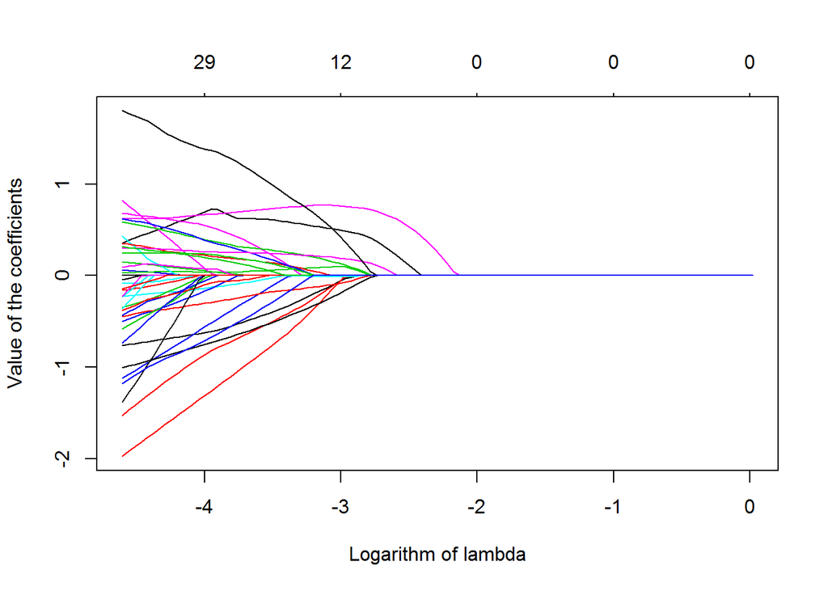

```r
## Create the x matrix
x <- model.matrix(trtfailure ~ ., data = TBtrain)[ , -which(names(TBtrain) %in% "trtfailure")]

## Create the y vector
y <- TBtrain$trtfailure

## Create a grid of lambda values
grid <- 10 ^ seq(0.01, -2, length = 100)

## Fit the Lasso model with unknown value for lambda
lassogrid <- glmnet(x, y, family = "binomial", alpha = 1, lambda = grid,
                    standardize = TRUE)
plot(lassogrid, xvar="lambda", xlab = "Logarithm of lambda",
     ylab = "Value of the coefficients")
```

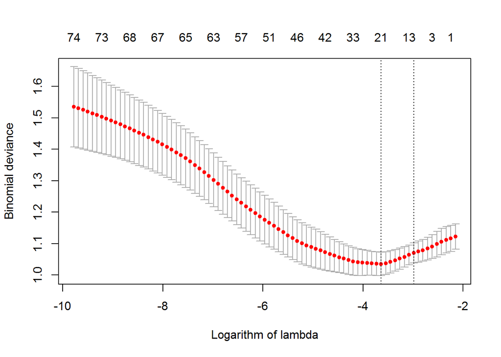

```r
## Set a seed with an arbitrary number
set.seed(11)

## Calculate the best value for lambda using cross validation
cvlasso <- cv.glmnet(x, y, family = "binomial", alpha = 1, nfold = 3)
plot(cvlasso, xlab = "Logarithm of lambda", ylab = "Binomial deviance")
```

```r
## Determine the best lambda value
bestlambda <- cvlasso$lambda.min
bestlambda
```

```
## [1] 0.02624217
```

```r
## Fit the Lasso model with the lambda value that minimizes error (deviance)
lasso <- glmnet(x, y, family = "binomial", alpha = 1, lambda = bestlambda,
                standardize = TRUE)

## Lasso model
lassocoefficients <- predict (lasso, type = "coefficients", s = bestlambda)
lassocoefficients
```

```
## 81 x 1 sparse Matrix of class "dgCMatrix"
##                                                         1
## (Intercept)                                 -1.1773254254
## countrybelarus                               .
## countrygeorgia                               0.6186254567
## countrymoldova                               .
## countryromania                              -0.6020822144
## age_of_onset                                 .
## gendermale                                   .
## educationcollegebachelor                     .
## educationcompleteschoolalevelgymnasium       .
## educationhigheruniversity                   -0.0636074081
## educationnotreported                         .
## employmentemployed                          -0.4711255738
## employmentnotreported                        .
## employmentretired                            .
## employmentstudent                           -0.9156208964
## employmentunemployed                         0.0474517626
## number_of_daily_contacts                     .
## type_of_resistancemono_dr                   -0.2362037168
## type_of_resistancenotreported                .
## type_of_resistancepoly_dr                    0.3380262708
## type_of_resistancesensitive                 -0.5860677978
## type_of_resistancexdr                        0.1626190799
## bmi                                          .
## lung_localizationpulmonary                   .
## lung_localizationpulmonaryandextrapulmonary  0.3010238790
## x_ray_count                                  .
## ct_count                                     .
## disseminationnotreported                     .
## disseminationyes                             .
## lungcavity_sizelessthan10mm                  .
## lungcavity_sizemorethan25mm                  0.7101667858
## lungcavity_sizenocavities                    .
## lungcavity_sizenotreported                   .
## affect_pleuranotreported                     .
## affect_pleurayes                             .
## shadow_patternnodemorethan10mm               .
## shadow_patternnoduleandnode                  .
## shadow_patternnodulelessthan10mm             .
```

[output cut: 28 more lines]

```
## social_risk_factorscurrentsmoker             0.1653709096
## social_risk_factorsdocumentedmdrcontact      .
## social_risk_factorsexprisoner                .
## social_risk_factorshomeless                  .
## social_risk_factorsnotreported               .
## social_risk_factorsregistereddrugabuse       .
## social_risk_factorsworkedabroad              .
## regimen_drugamoxicillinclavulanate           .
## regimen_drugantiretroviraltherapy            0.0976538478
## regimen_drugbedaquiline                     -0.4137666025
## regimen_drugcapreomycin                      .
## regimen_drugclofazimine                      .
## regimen_drugcycloserine                      .
## regimen_drugethambutol                       .
## regimen_drugnotreported                      .
```

```r
## Sparse LASSO model
lassosparse <- glmnet(x, y, family = "binomial", alpha = 1, lambda = cvlasso$lambda.1se,
                standardize = TRUE)

## Lasso model
lassosparsecoefficients <- predict (lassosparse, type = "coefficients", s = cvlasso$lambda.1se)
lassosparsecoefficients
```

```
## 81 x 1 sparse Matrix of class "dgCMatrix"
##                                                         1
## (Intercept)                                 -1.307542e+00
## countrybelarus                               .
## countrygeorgia                               4.928071e-01
## countrymoldova                               .
## countryromania                              -4.188899e-02
## age_of_onset                                 .
## gendermale                                   .
## educationcollegebachelor                     .
## educationcompleteschoolalevelgymnasium       .
## educationhigheruniversity                    .
## educationnotreported                         .
## employmentemployed                          -4.896739e-02
## employmentnotreported                        .
## employmentretired                            .
## employmentstudent                           -2.663454e-02
## employmentunemployed                         9.588959e-02
## number_of_daily_contacts                     .
## type_of_resistancemono_dr                    .
## type_of_resistancenotreported                .
## type_of_resistancepoly_dr                    .
## type_of_resistancesensitive                 -1.770798e-01
## type_of_resistancexdr                        .
## bmi                                          .
## lung_localizationpulmonary                   .
## lung_localizationpulmonaryandextrapulmonary  1.228450e-01
## x_ray_count                                  .
## ct_count                                     .
## disseminationnotreported                     .
## disseminationyes                             .
## lungcavity_sizelessthan10mm                  .
## lungcavity_sizemorethan25mm                  7.596384e-01
## lungcavity_sizenocavities                    .
## lungcavity_sizenotreported                   .
## affect_pleuranotreported                     .
## affect_pleurayes                             .
## shadow_patternnodemorethan10mm               .
## shadow_patternnoduleandnode                  .
## shadow_patternnodulelessthan10mm             .
```

[output cut: 28 more lines]

```
## social_risk_factorscurrentsmoker             .
## social_risk_factorsdocumentedmdrcontact      .
## social_risk_factorsexprisoner                .
## social_risk_factorshomeless                  .
## social_risk_factorsnotreported               .
## social_risk_factorsregistereddrugabuse       .
## social_risk_factorsworkedabroad              .
## regimen_drugamoxicillinclavulanate           .
## regimen_drugantiretroviraltherapy            .
## regimen_drugbedaquiline                      .
## regimen_drugcapreomycin                      .
## regimen_drugclofazimine                      .
## regimen_drugcycloserine                      .
## regimen_drugethambutol                       .
## regimen_drugnotreported                      .
```

## Random forests

Random forests fit several decorrelated decision trees to the data and “average” them so that the resulting model has as little bias and as little variance as possible. Decorrelated trees refer to the fact that in each decision node the variables to perform the next branch of each tree are only a subset of number mtry of the available variables ensuring that the individual trees are heterogeneous and capture the variability in the data.

```r
## Set a seed with an arbitrary number
set.seed(23)

## Divide the training set into 3 folds
folds <- sample(rep(1:3, length = nrow(TBtrain)))

## Make sure folds have more or less the same size
table(folds)
```

```
## folds
##   1   2   3
## 137 137 137
```

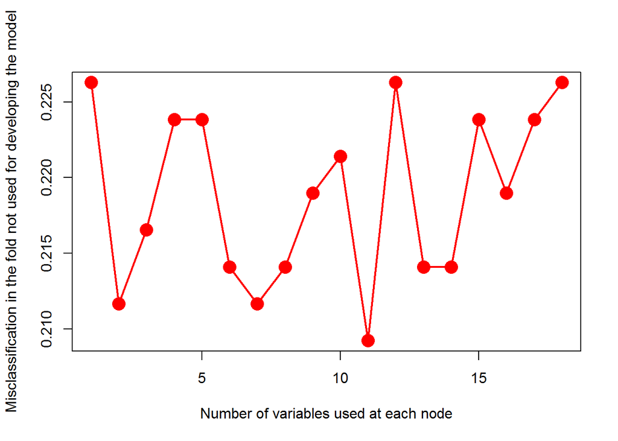

```r
## Find the random forest model with best mtry (number of variables
##considered in each decision node)
## Vector with different values for mtry from 1 to 19 (number of variables)
mtryvalues <- 1:18

## Set a seed with an arbitrary number
set.seed(9)

## Set an empty data frame with the proportion misclassified
##(rows will be different mtry, and columns values of k)
proportionerror <- data.frame(matrix(0, ncol = 3, nrow = 18))
colnames(proportionerror) <- c("k = 1", "k = 2", "k = 3")

## Calculate the best mtry by cross-validation
## Create a loop with 3 folds
for (k in 1 : 3) {
  ## Create a loop with 18 values of mtry
for (j in 1 : 18) {
  ## Calculate the random forest model based on 2 of the folds
forest <- randomForest(trtfailure ~ ., data = TBtrain[folds != k, ],
                       mtry = mtryvalues[j], ntree = 1000, importance = TRUE)
## Predict performance on the remaining fold not used for fitting the model
prediction <- predict(forest, newdata = TBtrain[folds == k,
                                                       - which(names(TBtrain) == "trtfailure")])
## Confusion matrix for the prediction
confusionmatrix <- table(prediction, TBtrain[folds
                                                    == k, which(names(TBtrain) == "trtfailure")])
## Misclassification error
proportionerror[j, k] <- (confusionmatrix[2, 1] + confusionmatrix[1, 2]) /
  (confusionmatrix[1, 1] + confusionmatrix[1, 2] +
     confusionmatrix[2, 1] + confusionmatrix[2, 2])
}
}

## Calculate the mean prediction error for each mtry
proportionerror$meanerror <- rowMeans(proportionerror)

## Plot the proportion of errors in relation with the number of variables in mtry
plot(mtryvalues, proportionerror$meanerror, pch = 16, cex = 2,
     col = "red", type = "o", lwd = 2,
     xlab = "Number of variables used at each node",
     ylab = "Misclassification in the fold not used for developing the model")
```

```r
## Identify the lowest mtry within 1 standard error of the mtry with minimum error
mtryminimumerror <- which(proportionerror$meanerror
                          == min(proportionerror$meanerror))[1]

## Calculate the definitive random forest in the full training set with the minimum error value of mtry
forest <- randomForest(trtfailure ~ ., data = TBtrain,
                       mtry = mtryminimumerror, ntree = 1000, importance = TRUE)
forest
```

```
##
## Call:
##  randomForest(formula = trtfailure ~ ., data = TBtrain, mtry = mtryminimumerror,      ntree = 1000, importance = TRUE)
##                Type of random forest: classification
##                      Number of trees: 1000
## No. of variables tried at each split: 11
##
##         OOB estimate of  error rate: 23.84%
## Confusion matrix:
##     0  1 class.error
## 0 286 22  0.07142857
## 1  76 27  0.73786408
```

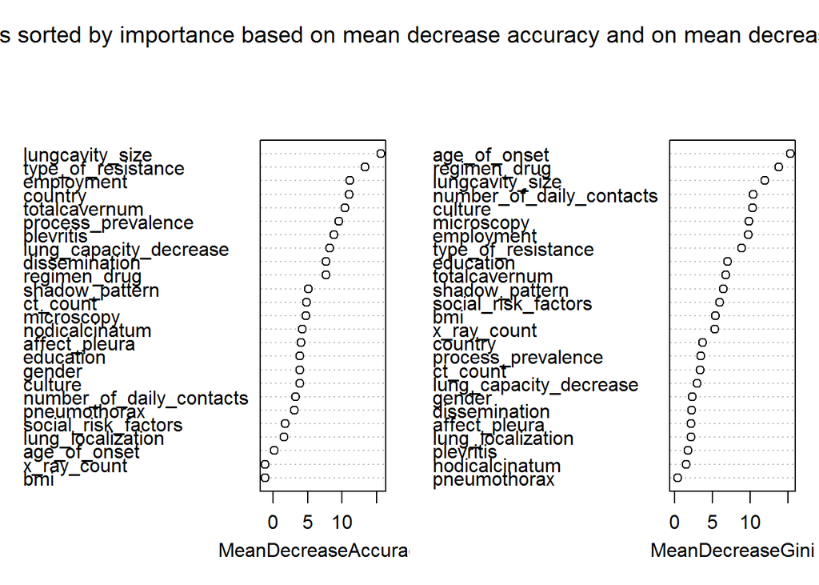

```r
varImpPlot(forest, main =
             "Variables sorted by importance based on mean decrease accuracy and on mean decreased Gini")
```

## Support vector machines: linear kernel

Support vector machines divide the observations by creating a boundary between the classes. As the observations might not be separable in their original dimension space, support vector machines separate the observations in a higher dimensional space that is visited through a kernel.

```r
## Set a seed with an arbitrary number
set.seed(33)

## Support vector machine with a radial kernel tune best model using 3 fold cross-validation
svmparameterslinear <- tune(svm, trtfailure ~ ., data = TBtrain,
                            kernel = "linear",
                            ranges = list(cost = seq(0.01, 2, 0.05)),
                      tunecontrol = tune.control(cross = 3),
                      scale = TRUE, probability = TRUE)

## Parameters for the best model
svmparameterslinear
```

```
##
## Parameter tuning of 'svm':
##
## - sampling method: 3-fold cross validation
##
## - best parameters:
##  cost
##  0.11
##
## - best performance: 0.2287105
```

```r
## Select the best model
svmlinear <- svmparameterslinear$best.model
svmlinear
```

```
##
## Call:
## best.tune(method = svm, train.x = trtfailure ~ ., data = TBtrain,
##     ranges = list(cost = seq(0.01, 2, 0.05)), tunecontrol = tune.control(cross = 3),
##     kernel = "linear", scale = TRUE, probability = TRUE)
##
##
## Parameters:
##    SVM-Type:  C-classification
##  SVM-Kernel:  linear
##        cost:  0.11
##       gamma:  0.01234568
##
## Number of Support Vectors:  220
```

## Support vector machines: polynomial kernel

```r
## Set a seed with an arbitrary number
set.seed(52)

## Support vector machine with a polynomial kernel tune best model using 3 fold cross-validation
svmparameterspolynomial <- tune(svm, trtfailure ~ ., data = TBtrain,
                            kernel = "polynomial",
                            ranges = list(cost = seq(0.01, 2, 0.05),
                                          degree = seq(1, 6, 1)),
                      tunecontrol = tune.control(cross = 3),
                      scale = TRUE, probability = TRUE)

## Parameters for the best model
svmparameterspolynomial
```

```
##
## Parameter tuning of 'svm':
##
## - sampling method: 3-fold cross validation
##
## - best parameters:
##  cost degree
##  1.81      1
##
## - best performance: 0.2481752
```

```r
## Select the best model
svmpolynomial <- svmparameterspolynomial$best.model
svmpolynomial
```

```
##
## Call:
## best.tune(method = svm, train.x = trtfailure ~ ., data = TBtrain,
##     ranges = list(cost = seq(0.01, 2, 0.05), degree = seq(1,
##         6, 1)), tunecontrol = tune.control(cross = 3), kernel = "polynomial",
##     scale = TRUE, probability = TRUE)
##
##
## Parameters:
##    SVM-Type:  C-classification
##  SVM-Kernel:  polynomial
##        cost:  1.81
##      degree:  1
##       gamma:  0.01234568
##      coef.0:  0
##
## Number of Support Vectors:  224
```

## TESTING THE PERFORMANCE OF THE DIFFERENT METHODS IN THE TESTING SET

## Forward stepwise selection

```r
## Prediction based on area under the curve
predictionforward <- predict(forward, type = "response",
                             newdata = TBtest[ , - which(names(TBtest) == "trtfailure")])
aucforward <- auc(TBtest$trtfailure, predictionforward)
aucforward
```

```
## Area under the curve: 0.7427
```

```r
ciforward <- ci.auc(TBtest$trtfailure, predictionforward)
ciforward
```

```
## 95% CI: 0.6627-0.8227 (DeLong)
```

```r
## Prediction based on misclassification error
predictionforward01 <- ifelse(predictionforward > 0.5, 1, 0)
predictionforward01 <- as.factor(predictionforward01)
confusionmatrix <- table(predictionforward01,
                         TBtest[ , which(names(TBtest) == "trtfailure")])
misclassificationforward <- (confusionmatrix[2, 1] + confusionmatrix[1, 2]) /
  (confusionmatrix[1, 1] + confusionmatrix[1, 2] + confusionmatrix[2, 1] + confusionmatrix[2, 2])
misclassificationforward
```

```
## [1] 0.2386364
```

```r
## Prediction based on sensitivity, specificity, positive predictive value,
##and negative predictive value
sensitivityforward <- confusionmatrix[2, 2] /
  (confusionmatrix[1, 2] + confusionmatrix[2, 2])
sensitivityforward
```

```
## [1] 0.3636364
```

```r
specificityforward <- confusionmatrix[1, 1] /
  (confusionmatrix[1, 1] + confusionmatrix[2, 1])
specificityforward
```

```
## [1] 0.8939394
```

```r
ppvforward <- confusionmatrix[2, 2] /
  (confusionmatrix[2, 1] + confusionmatrix[2, 2])
ppvforward
```

```
## [1] 0.5333333
```

```r
npvforward <- confusionmatrix[1, 1] /
  (confusionmatrix[1, 1] + confusionmatrix[1, 2])
npvforward
```

```
## [1] 0.8082192
```

```r
## Calculate optimal threshold with Youden's index
rocforward <- roc(TBtest$trtfailure, predictionforward)
bestforward <- coords(rocforward, "b", ret = "threshold", best.method = "youden")
bestforward
```

```
## [1] 0.1688521
```

```r
## Prediction based on misclassification error
predictionforwardyouden01 <- ifelse(predictionforward > bestforward, 1, 0)
predictionforwardyouden01 <- as.factor(predictionforwardyouden01)
confusionmatrix <- table(predictionforwardyouden01,
                         TBtest[ , which(names(TBtest) == "trtfailure")])
misclassificationforwardyouden <- (confusionmatrix[2, 1] + confusionmatrix[1, 2]) /
  (confusionmatrix[1, 1] + confusionmatrix[1, 2] + confusionmatrix[2, 1] + confusionmatrix[2, 2])
misclassificationforwardyouden
```

```
## [1] 0.3693182
```

```r
## Prediction based on sensitivity, specificity, positive predictive value,
##and negative predictive value
sensitivityforwardyouden <- confusionmatrix[2, 2] /
  (confusionmatrix[1, 2] + confusionmatrix[2, 2])
sensitivityforwardyouden
```

```
## [1] 0.8636364
```

```r
specificityforwardyouden <- confusionmatrix[1, 1] /
  (confusionmatrix[1, 1] + confusionmatrix[2, 1])
specificityforwardyouden
```

```
## [1] 0.5530303
```

```r
ppvforwardyouden <- confusionmatrix[2, 2] /
  (confusionmatrix[2, 1] + confusionmatrix[2, 2])
ppvforwardyouden
```

```
## [1] 0.3917526
```

```r
npvforwardyouden <- confusionmatrix[1, 1] /
  (confusionmatrix[1, 1] + confusionmatrix[1, 2])
npvforwardyouden
```

```
## [1] 0.9240506
```

## Backward stepwise elimination

```r
## Prediction based on area under the curve
predictionbackward <- predict(backward, type = "response",
                              newdata = TBtest[ , - which(names(TBtest) == "trtfailure")])
aucbackward <- auc(TBtest$trtfailure, predictionbackward)
aucbackward
```

```
## Area under the curve: 0.7276
```

```r
cibackward <- ci.auc(TBtest$trtfailure, predictionbackward)
cibackward
```

```
## 95% CI: 0.6475-0.8078 (DeLong)
```

```r
## Prediction based on misclassification error
predictionbackward01 <- ifelse(predictionbackward > 0.5, 1, 0)
predictionbackward01 <- as.factor(predictionbackward01)
confusionmatrix <- table(predictionbackward01,
                         TBtest[ , which(names(TBtest) == "trtfailure")])
misclassificationbackward <- (confusionmatrix[2, 1] + confusionmatrix[1, 2]) /
  (confusionmatrix[1, 1] + confusionmatrix[1, 2] + confusionmatrix[2, 1] + confusionmatrix[2, 2])
misclassificationbackward
```

```
## [1] 0.2670455
```

```r
## Prediction based on sensitivity, specificity, positive predictive value,
##and negative predictive value
sensitivitybackward <- confusionmatrix[2, 2] /
  (confusionmatrix[1, 2] + confusionmatrix[2, 2])
sensitivitybackward
```

```
## [1] 0.2954545
```

```r
specificitybackward <- confusionmatrix[1, 1] /
  (confusionmatrix[1, 1] + confusionmatrix[2, 1])
specificitybackward
```

```
## [1] 0.8787879
```

```r
ppvbackward <- confusionmatrix[2, 2] /
  (confusionmatrix[2, 1] + confusionmatrix[2, 2])
ppvbackward
```

```
## [1] 0.4482759
```

```r
npvbackward <- confusionmatrix[1, 1] /
  (confusionmatrix[1, 1] + confusionmatrix[1, 2])
npvbackward
```

```
## [1] 0.7891156
```

```r
## Calculate optimal threshold with Youden's index
rocbackward <- roc(TBtest$trtfailure, predictionbackward)
bestbackward <- coords(rocbackward, "b", ret = "threshold", best.method = "youden")

## Prediction based on misclassification error
predictionbackwardyouden01 <- ifelse(predictionbackward > bestbackward[1], 1, 0)
predictionbackwardyouden01 <- as.factor(predictionbackwardyouden01)
confusionmatrix <- table(predictionbackwardyouden01,
                         TBtest[ , which(names(TBtest) == "trtfailure")])
misclassificationbackwardyouden <- (confusionmatrix[2, 1] + confusionmatrix[1, 2]) /
  (confusionmatrix[1, 1] + confusionmatrix[1, 2] + confusionmatrix[2, 1] + confusionmatrix[2, 2])
misclassificationbackwardyouden
```

```
## [1] 0.3977273
```

```r
## Prediction based on sensitivity, specificity, positive predictive value,
##and negative predictive value
sensitivitybackwardyouden <- confusionmatrix[2, 2] /
  (confusionmatrix[1, 2] + confusionmatrix[2, 2])
sensitivitybackwardyouden
```

```
## [1] 0.8636364
```

```r
specificitybackwardyouden <- confusionmatrix[1, 1] /
  (confusionmatrix[1, 1] + confusionmatrix[2, 1])
specificitybackwardyouden
```

```
## [1] 0.5151515
```

```r
ppvbackwardyouden <- confusionmatrix[2, 2] /
  (confusionmatrix[2, 1] + confusionmatrix[2, 2])
ppvbackwardyouden
```

```
## [1] 0.372549
```

```r
npvbackwardyouden <- confusionmatrix[1, 1] /
  (confusionmatrix[1, 1] + confusionmatrix[1, 2])
npvbackwardyouden
```

```
## [1] 0.9189189
```

## Stepwise selection with both backward elimination and forward selection

```r
## Prediction based on area under the curve
predictionboth <- predict(both, type = "response", newdata =
                            TBtest[ , - which(names(TBtest) == "trtfailure")])
aucboth <- auc(TBtest$trtfailure, predictionboth)
aucboth
```

```
## Area under the curve: 0.7276
```

```r
ciboth <- ci.auc(TBtest$trtfailure, predictionboth)
ciboth
```

```
## 95% CI: 0.6475-0.8078 (DeLong)
```

```r
## Prediction based on misclassification error
predictionboth01 <- ifelse(predictionboth > 0.5, 1, 0)
predictionboth01 <- as.factor(predictionboth01)
confusionmatrix <- table(predictionboth01,
                         TBtest[ , which(names(TBtest) == "trtfailure")])
misclassificationboth <- (confusionmatrix[2, 1] + confusionmatrix[1, 2]) /
  (confusionmatrix[1, 1] + confusionmatrix[1, 2] + confusionmatrix[2, 1] + confusionmatrix[2, 2])
misclassificationboth
```

```
## [1] 0.2670455
```

```r
## Prediction based on sensitivity, specificity, positive predictive value,
##and negative predictive value
sensitivityboth <- confusionmatrix[2, 2] /
  (confusionmatrix[1, 2] + confusionmatrix[2, 2])
sensitivityboth
```

```
## [1] 0.2954545
```

```r
specificityboth <- confusionmatrix[1, 1] /
  (confusionmatrix[1, 1] + confusionmatrix[2, 1])
specificityboth
```

```
## [1] 0.8787879
```

```r
ppvboth <- confusionmatrix[2, 2] /
  (confusionmatrix[2, 1] + confusionmatrix[2, 2])
ppvboth
```

```
## [1] 0.4482759
```

```r
npvboth <- confusionmatrix[1, 1] /
  (confusionmatrix[1, 1] + confusionmatrix[1, 2])
npvboth
```

```
## [1] 0.7891156
```

```r
## Calculate optimal threshold with Youden's index
rocboth <- roc(TBtest$trtfailure, predictionboth)
bestboth <- coords(rocboth, "b", ret = "threshold", best.method = "youden")
bestboth
```

```
##                best      best
## threshold 0.1520286 0.2368976
```

```r
## Prediction based on misclassification error
predictionbothyouden01 <- ifelse(predictionboth > bestboth[1], 1, 0)
predictionbothyouden01 <- as.factor(predictionbothyouden01)
confusionmatrix <- table(predictionbothyouden01,
                         TBtest[ , which(names(TBtest) == "trtfailure")])
misclassificationbothyouden <- (confusionmatrix[2, 1] + confusionmatrix[1, 2]) /
  (confusionmatrix[1, 1] + confusionmatrix[1, 2] + confusionmatrix[2, 1] + confusionmatrix[2, 2])
misclassificationbothyouden
```

```
## [1] 0.3977273
```

```r
## Prediction based on sensitivity, specificity, positive predictive value,
##and negative predictive value
sensitivitybothyouden <- confusionmatrix[2, 2] /
  (confusionmatrix[1, 2] + confusionmatrix[2, 2])
sensitivitybothyouden
```

```
## [1] 0.8636364
```

```r
specificitybothyouden <- confusionmatrix[1, 1] /
  (confusionmatrix[1, 1] + confusionmatrix[2, 1])
specificitybothyouden
```

```
## [1] 0.5151515
```

```r
ppvbothyouden <- confusionmatrix[2, 2] /
  (confusionmatrix[2, 1] + confusionmatrix[2, 2])
ppvbothyouden
```

```
## [1] 0.372549
```

```r
npvbothyouden <- confusionmatrix[1, 1] /
  (confusionmatrix[1, 1] + confusionmatrix[1, 2])
npvbothyouden
```

```
## [1] 0.9189189
```

## Lasso

```r
## Prediction based on area under the curve
## Create the x matrix
x <- model.matrix(trtfailure ~ ., data = TBtest)[ , -which(names(TBtest) %in% "trtfailure")]
## Create the y vector
y <- TBtest$trtfailure
## Lasso predictions
predictionlasso <- predict(lasso, newx = x, type = "response")
predictionlasso <- as.numeric(predictionlasso)
## Area under the curve
auclasso <- auc(TBtest$trtfailure, predictionlasso)
auclasso
```

```
## Area under the curve: 0.7176
```

```r
cilasso <- ci.auc(TBtest$trtfailure, predictionlasso)
cilasso
```

```
## 95% CI: 0.6367-0.7986 (DeLong)
```

```r
## Prediction based on misclassification error
predictionlasso01 <- ifelse(predictionlasso > 0.5, 1, 0)
predictionlasso01 <- as.factor(predictionlasso01)
confusionmatrix <- table(predictionlasso01,
                         TBtest[ , which(names(TBtest) == "trtfailure")])
misclassificationlasso <- (confusionmatrix[2, 1] + confusionmatrix[1, 2]) /
  (confusionmatrix[1, 1] + confusionmatrix[1, 2] + confusionmatrix[2, 1] + confusionmatrix[2, 2])
misclassificationlasso
```

```
## [1] 0.2272727
```

```r
## Prediction based on sensitivity, specificity, positive predictive value,
##and negative predictive value
sensitivitylasso <- confusionmatrix[2, 2] /
  (confusionmatrix[1, 2] + confusionmatrix[2, 2])
sensitivitylasso
```

```
## [1] 0.2045455
```

```r
specificitylasso <- confusionmatrix[1, 1] /
  (confusionmatrix[1, 1] + confusionmatrix[2, 1])
specificitylasso
```

```
## [1] 0.9621212
```

```r
ppvlasso <- confusionmatrix[2, 2] /
  (confusionmatrix[2, 1] + confusionmatrix[2, 2])
ppvlasso
```

```
## [1] 0.6428571
```

```r
npvlasso <- confusionmatrix[1, 1] /
  (confusionmatrix[1, 1] + confusionmatrix[1, 2])
npvlasso
```

```
## [1] 0.7839506
```

```r
## Calculate optimal threshold with Youden's index
roclasso <- roc(TBtest$trtfailure, predictionlasso)
bestlasso <- coords(roclasso, "b", ret = "threshold", best.method = "youden")
bestlasso
```

```
## [1] 0.2040404
```

```r
## Prediction based on misclassification error
predictionlassoyouden01 <- ifelse(predictionlasso > bestlasso, 1, 0)
predictionlassoyouden01 <- as.factor(predictionlassoyouden01)
confusionmatrix <- table(predictionlassoyouden01,
                         TBtest[ , which(names(TBtest) == "trtfailure")])
misclassificationlassoyouden <- (confusionmatrix[2, 1] + confusionmatrix[1, 2]) /
  (confusionmatrix[1, 1] + confusionmatrix[1, 2] + confusionmatrix[2, 1] + confusionmatrix[2, 2])
misclassificationlassoyouden
```

```
## [1] 0.4375
```

```r
## Prediction based on sensitivity, specificity, positive predictive value,
##and negative predictive value
sensitivitylassoyouden <- confusionmatrix[2, 2] /
  (confusionmatrix[1, 2] + confusionmatrix[2, 2])
sensitivitylassoyouden
```

```
## [1] 0.9090909
```

```r
specificitylassoyouden <- confusionmatrix[1, 1] /
  (confusionmatrix[1, 1] + confusionmatrix[2, 1])
specificitylassoyouden
```

```
## [1] 0.4469697
```

```r
ppvlassoyouden <- confusionmatrix[2, 2] /
  (confusionmatrix[2, 1] + confusionmatrix[2, 2])
ppvlassoyouden
```

```
## [1] 0.3539823
```

```r
npvlassoyouden <- confusionmatrix[1, 1] /
  (confusionmatrix[1, 1] + confusionmatrix[1, 2])
npvlassoyouden
```

```
## [1] 0.9365079
```

## Random Forests

```r
## Prediction based on area under the curve
predictionforest <- predict(forest, type = "prob", newdata =
                              TBtest[ , - which(names(TBtest) == "trtfailure")])[ , 2]
aucforest <- auc(TBtest$trtfailure, predictionforest)
aucforest
```

```
## Area under the curve: 0.7035
```

```r
ciforest <- ci.auc(TBtest$trtfailure, predictionforest)
ciforest
```

```
## 95% CI: 0.6152-0.7918 (DeLong)
```

```r
## Prediction based on misclassification error
predictionforest01 <- predict(forest,
                              newdata = TBtest[ , - which(names(TBtest) == "trtfailure")])
confusionmatrix <- table(predictionforest01,
                         TBtest[ , which(names(TBtest) == "trtfailure")])
misclassificationforest <- (confusionmatrix[2, 1] + confusionmatrix[1, 2]) /
  (confusionmatrix[1, 1] + confusionmatrix[1, 2] + confusionmatrix[2, 1] + confusionmatrix[2, 2])
misclassificationforest
```

```
## [1] 0.2443182
```

```r
## Prediction based on sensitivity, specificity, positive predictive value,
##and negative predictive value
sensitivityforest <- confusionmatrix[2, 2] /
  (confusionmatrix[1, 2] + confusionmatrix[2, 2])
sensitivityforest
```

```
## [1] 0.2954545
```

```r
specificityforest <- confusionmatrix[1, 1] /
  (confusionmatrix[1, 1] + confusionmatrix[2, 1])
specificityforest
```

```
## [1] 0.9090909
```

```r
ppvforest <- confusionmatrix[2, 2] /
  (confusionmatrix[2, 1] + confusionmatrix[2, 2])
ppvforest
```

```
## [1] 0.52
```

```r
npvforest <- confusionmatrix[1, 1] /
  (confusionmatrix[1, 1] + confusionmatrix[1, 2])
npvforest
```

```
## [1] 0.794702
```

```r
## Calculate optimal threshold with Youden's index
rocforest <- roc(TBtest$trtfailure, predictionforest)
bestforest <- coords(rocforest, "b", ret = "threshold", best.method = "youden")
bestforest
```

```
## [1] 0.31
```

```r
## Prediction based on misclassification error
predictionforestyouden01 <- ifelse(predictionforest > bestforest, 1, 0)
predictionforestyouden01 <- as.factor(predictionforestyouden01)
confusionmatrix <- table(predictionforestyouden01,
                         TBtest[ , which(names(TBtest) == "trtfailure")])
misclassificationforestyouden <- (confusionmatrix[2, 1] + confusionmatrix[1, 2]) /
  (confusionmatrix[1, 1] + confusionmatrix[1, 2] + confusionmatrix[2, 1] + confusionmatrix[2, 2])
misclassificationforestyouden
```

```
## [1] 0.2897727
```

```r
## Prediction based on sensitivity, specificity, positive predictive value,
##and negative predictive value
sensitivityforestyouden <- confusionmatrix[2, 2] /
  (confusionmatrix[1, 2] + confusionmatrix[2, 2])
sensitivityforestyouden
```

```
## [1] 0.6363636
```

```r
specificityforestyouden <- confusionmatrix[1, 1] /
  (confusionmatrix[1, 1] + confusionmatrix[2, 1])
specificityforestyouden
```

```
## [1] 0.7348485
```

```r
ppvforestyouden <- confusionmatrix[2, 2] /
  (confusionmatrix[2, 1] + confusionmatrix[2, 2])
ppvforestyouden
```

```
## [1] 0.4444444
```

```r
npvforestyouden <- confusionmatrix[1, 1] /
  (confusionmatrix[1, 1] + confusionmatrix[1, 2])
npvforestyouden
```

```
## [1] 0.8584071
```

## Support vector machines: linear kernel

```r
## Prediction based on area under the curve
predictionsvmlinear <- predict(svmlinear, probability = TRUE,
                               newdata = TBtest[ , - which(names(TBtest) == "trtfailure")])
predictionsvmlinear <- attr(predictionsvmlinear, "probabilities")[ , 2]
aucsvmlinear <- auc(TBtest$trtfailure, predictionsvmlinear)
aucsvmlinear
```

```
## Area under the curve: 0.6863
```

```r
cisvmlinear <- ci.auc(TBtest$trtfailure, predictionsvmlinear)
cisvmlinear
```

```
## 95% CI: 0.5985-0.7741 (DeLong)
```

```r
## Prediction based on misclassification error
predictionsvmlinear01 <- predict(svmlinear,
                                 newdata = TBtest[ , - which(names(TBtest) == "trtfailure")])
confusionmatrix <- table(predictionsvmlinear01, TBtest[ , which(names(TBtest) == "trtfailure")])
misclassificationsvmlinear <- (confusionmatrix[2, 1] + confusionmatrix[1, 2]) /
  (confusionmatrix[1, 1] + confusionmatrix[1, 2] + confusionmatrix[2, 1] + confusionmatrix[2, 2])
misclassificationsvmlinear
```

```
## [1] 0.2386364
```

```r
## Prediction based on sensitivity, specificity, positive predictive value,
##and negative predictive value
sensitivitysvmlinear <- confusionmatrix[2, 2] /
  (confusionmatrix[1, 2] + confusionmatrix[2, 2])
sensitivitysvmlinear
```

```
## [1] 0.2045455
```

```r
specificitysvmlinear <- confusionmatrix[1, 1] /
  (confusionmatrix[1, 1] + confusionmatrix[2, 1])
specificitysvmlinear
```

```
## [1] 0.9469697
```

```r
ppvsvmlinear <- confusionmatrix[2, 2] /
  (confusionmatrix[2, 1] + confusionmatrix[2, 2])
ppvsvmlinear
```

```
## [1] 0.5625
```

```r
npvsvmlinear <- confusionmatrix[1, 1] /
  (confusionmatrix[1, 1] + confusionmatrix[1, 2])
npvsvmlinear
```

```
## [1] 0.78125
```

```r
## Calculate optimal threshold with Youden's index
rocsvmlinear <- roc(TBtest$trtfailure, predictionsvmlinear)
bestsvmlinear <- coords(rocsvmlinear, "b", ret = "threshold", best.method = "youden")
bestsvmlinear
```

```
## [1] 0.2573071
```

```r
## Prediction based on misclassification error
predictionsvmlinearyouden01 <- ifelse(predictionsvmlinear > bestsvmlinear, 1, 0)
predictionsvmlinearyouden01 <- as.factor(predictionsvmlinearyouden01)
confusionmatrix <- table(predictionsvmlinearyouden01,
                         TBtest[ , which(names(TBtest) == "trtfailure")])
misclassificationsvmlinearyouden <- (confusionmatrix[2, 1] + confusionmatrix[1, 2]) /
  (confusionmatrix[1, 1] + confusionmatrix[1, 2] + confusionmatrix[2, 1] + confusionmatrix[2, 2])
misclassificationsvmlinearyouden
```

```
## [1] 0.3352273
```

```r
## Prediction based on sensitivity, specificity, positive predictive value,
##and negative predictive value
sensitivitysvmlinearyouden <- confusionmatrix[2, 2] /
  (confusionmatrix[1, 2] + confusionmatrix[2, 2])
sensitivitysvmlinearyouden
```

```
## [1] 0.5909091
```

```r
specificitysvmlinearyouden <- confusionmatrix[1, 1] /
  (confusionmatrix[1, 1] + confusionmatrix[2, 1])
specificitysvmlinearyouden
```

```
## [1] 0.6893939
```

```r
ppvsvmlinearyouden <- confusionmatrix[2, 2] /
  (confusionmatrix[2, 1] + confusionmatrix[2, 2])
ppvsvmlinearyouden
```

```
## [1] 0.3880597
```

```r
npvsvmlinearyouden <- confusionmatrix[1, 1] /
  (confusionmatrix[1, 1] + confusionmatrix[1, 2])
npvsvmlinearyouden
```

```
## [1] 0.8348624
```

## Support vector machines: polynomial kernel

```r
## Prediction based on area under the curve
predictionsvmpolynomial <- predict(svmpolynomial,
                                   probability = TRUE,
                                   newdata = TBtest[ , - which(names(TBtest) == "trtfailure")])
predictionsvmpolynomial <- attr(predictionsvmpolynomial, "probabilities")[ , 2]
aucsvmpolynomial <- auc(TBtest$trtfailure, predictionsvmpolynomial)
aucsvmpolynomial
```

```
## Area under the curve: 0.6852
```

```r
cisvmpolynomial <- ci.auc(TBtest$trtfailure, predictionsvmpolynomial)
cisvmpolynomial
```

```
## 95% CI: 0.5972-0.7731 (DeLong)
```

```r
## Prediction based on misclassification error
predictionsvmpolynomial01 <- predict(svmpolynomial,
                                     newdata = TBtest[ , - which(names(TBtest) == "trtfailure")])
confusionmatrix <- table(predictionsvmpolynomial01,
                         TBtest[ , which(names(TBtest) == "trtfailure")])
misclassificationsvmpolynomial <- (confusionmatrix[2, 1] + confusionmatrix[1, 2]) /
  (confusionmatrix[1, 1] + confusionmatrix[1, 2] + confusionmatrix[2, 1] + confusionmatrix[2, 2])
misclassificationsvmpolynomial
```

```
## [1] 0.25
```

```r
## Prediction based on sensitivity, specificity, positive predictive value,
##and negative predictive value
sensitivitysvmpolynomial <- confusionmatrix[2, 2] /
  (confusionmatrix[1, 2] + confusionmatrix[2, 2])
sensitivitysvmpolynomial
```

```
## [1] 0
```

```r
specificitysvmpolynomial <- confusionmatrix[1, 1] /
  (confusionmatrix[1, 1] + confusionmatrix[2, 1])
specificitysvmpolynomial
```

```
## [1] 1
```

```r
ppvsvmpolynomial <- confusionmatrix[2, 2] /
  (confusionmatrix[2, 1] + confusionmatrix[2, 2])
ppvsvmpolynomial
```

```
## [1] NaN
```

```r
npvsvmpolynomial <- confusionmatrix[1, 1] /
  (confusionmatrix[1, 1] + confusionmatrix[1, 2])
npvsvmpolynomial
```

```
## [1] 0.75
```

```r
## Calculate optimal threshold with Youden's index
rocsvmpolynomial <- roc(TBtest$trtfailure, predictionsvmpolynomial)
bestsvmpolynomial <- coords(rocsvmpolynomial, "b", ret = "threshold", best.method = "youden")
bestsvmpolynomial
```

```
## [1] 0.2654367
```

```r
## Prediction based on misclassification error
predictionsvmpolynomialyouden01 <- ifelse(predictionsvmpolynomial > bestsvmpolynomial, 1, 0)
predictionsvmpolynomialyouden01 <- as.factor(predictionsvmpolynomialyouden01)
confusionmatrix <- table(predictionsvmpolynomialyouden01,
                         TBtest[ , which(names(TBtest) == "trtfailure")])
misclassificationsvmpolynomialyouden <- (confusionmatrix[2, 1] + confusionmatrix[1, 2]) /
  (confusionmatrix[1, 1] + confusionmatrix[1, 2] + confusionmatrix[2, 1] + confusionmatrix[2, 2])
misclassificationsvmpolynomialyouden
```

```
## [1] 0.3068182
```

```r
## Prediction based on sensitivity, specificity, positive predictive value,
##and negative predictive value
sensitivitysvmpolynomialyouden <- confusionmatrix[2, 2] /
  (confusionmatrix[1, 2] + confusionmatrix[2, 2])
sensitivitysvmpolynomialyouden
```

```
## [1] 0.5227273
```

```r
specificitysvmpolynomialyouden <- confusionmatrix[1, 1] /
  (confusionmatrix[1, 1] + confusionmatrix[2, 1])
specificitysvmpolynomialyouden
```

```
## [1] 0.75
```

```r
ppvsvmpolynomialyouden <- confusionmatrix[2, 2] /
  (confusionmatrix[2, 1] + confusionmatrix[2, 2])
ppvsvmpolynomialyouden
```

```
## [1] 0.4107143
```

```r
npvsvmpolynomialyouden <- confusionmatrix[1, 1] /
  (confusionmatrix[1, 1] + confusionmatrix[1, 2])
npvsvmpolynomialyouden
```

```
## [1] 0.825
```

## FINAL RESULTS

```r
## Model names
modelnames <- c("Forward",
                "Backward", "Forward and backward", "Lasso", "Random Forest",
                "SVM linear", "SVM polynomial")

## Outcome names
outcomenames <- c("AUC", "AUC 95%CI: lower", "AUC 95%CI: upper",
                  "Misclassification",
                  "Sensitivity", "Specificity", "PPV", "NPV")

## Model area under the curve
modelauc <- c(aucforward,
              aucbackward, aucboth, auclasso, aucforest, aucsvmlinear,
              aucsvmpolynomial)

## Model confidence interval for area under the curve: lower
modelcilower <- c(ciforward[1], cibackward[1], ciboth[1], cilasso[1], ciforest[1],
                  cisvmlinear[1], cisvmpolynomial[1])

## Model confidence interval for area under the curve: upper
modelciupper <- c(ciforward[3], cibackward[3], ciboth[3], cilasso[3], ciforest[3],
                  cisvmlinear[3], cisvmpolynomial[3])


## Model misclassification error
modelmisclassification <- c(misclassificationforward, misclassificationbackward,
                            misclassificationboth, misclassificationlasso,
                            misclassificationforest, misclassificationsvmlinear,
                            misclassificationsvmpolynomial)

## Model sensitivity
modelsensitivity <- c(sensitivityforward, sensitivitybackward, sensitivityboth,
                      sensitivitylasso, sensitivityforest, sensitivitysvmlinear,
                      sensitivitysvmpolynomial)

## Model specificity
modelspecificity <- c(specificityforward,
                      specificitybackward, specificityboth, specificitylasso, specificityforest,
                      specificitysvmlinear, specificitysvmpolynomial)

## Model positive predictive value
modelppv <- c(ppvforward, ppvbackward, ppvboth, ppvlasso,
              ppvforest, ppvsvmlinear, ppvsvmpolynomial)

## Negative predictive value
modelnpv <- c(npvforward, npvbackward, npvboth, npvlasso,
              npvforest, npvsvmlinear, npvsvmpolynomial)

## Final table
results <- data.frame(modelauc, modelcilower, modelciupper,
                      modelmisclassification, modelsensitivity, modelspecificity, modelppv,
                      modelnpv)
rownames(results) <- modelnames
colnames(results) <- outcomenames
results
```

```
##                            AUC AUC 95%CI: lower AUC 95%CI: upper
## Forward              0.7426825        0.6627016        0.8226634
## Backward             0.7276171        0.6474651        0.8077691
## Forward and backward 0.7276171        0.6474651        0.8077691
## Lasso                0.7176309        0.6367105        0.7985512
## Random Forest        0.7035124        0.6151755        0.7918492
## SVM linear           0.6862948        0.5985290        0.7740605
## SVM polynomial       0.6851756        0.5972485        0.7731027
##                      Misclassification Sensitivity Specificity       PPV
## Forward                      0.2386364   0.3636364   0.8939394 0.5333333
## Backward                     0.2670455   0.2954545   0.8787879 0.4482759
## Forward and backward         0.2670455   0.2954545   0.8787879 0.4482759
## Lasso                        0.2272727   0.2045455   0.9621212 0.6428571
## Random Forest                0.2443182   0.2954545   0.9090909 0.5200000
## SVM linear                   0.2386364   0.2045455   0.9469697 0.5625000
## SVM polynomial               0.2500000   0.0000000   1.0000000       NaN
##                            NPV
## Forward              0.8082192
## Backward             0.7891156
## Forward and backward 0.7891156
## Lasso                0.7839506
## Random Forest        0.7947020
## SVM linear           0.7812500
## SVM polynomial       0.7500000
```

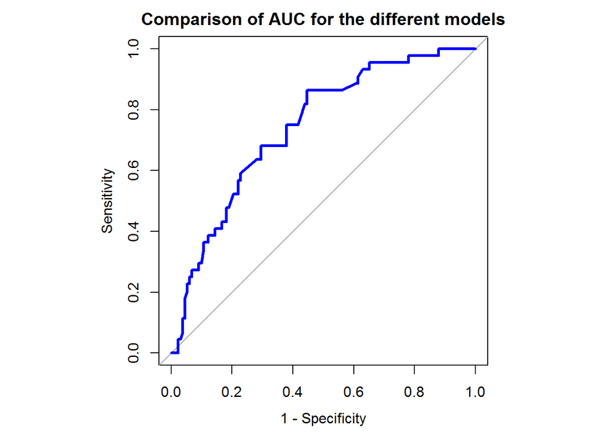

```r
## For improved graphs (remove dead space left & right)
par(pty="s")

## Area under the curve graph individual
plot.roc(roc(TBtest$trtfailure, predictionforward), col = "blue", lwd = 3,
         main = "Comparison of AUC for the different models", xlab = "1 - Specificity", legacy.axes = TRUE)
```

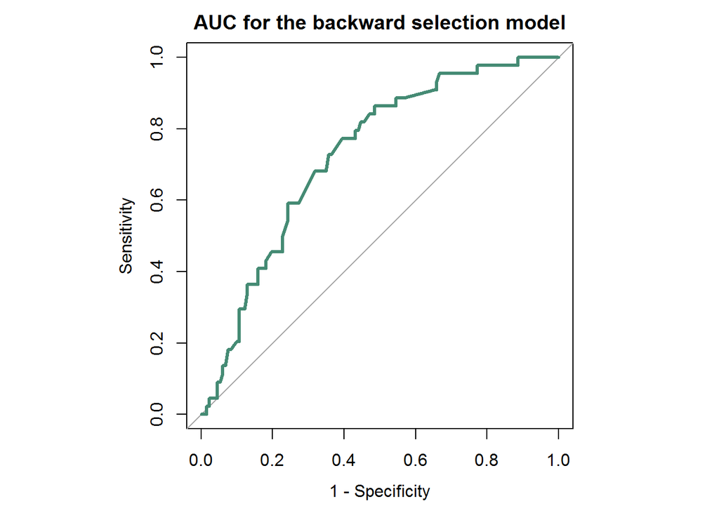

```r
plot.roc(roc(TBtest$trtfailure, predictionbackward), col = "aquamarine4", lwd = 3,
         main = "AUC for the backward selection model", xlab = "1 - Specificity", legacy.axes = TRUE)
```

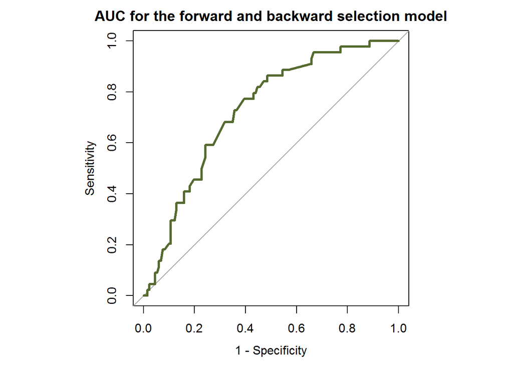

```r
plot.roc(roc(TBtest$trtfailure, predictionboth), col = "darkolivegreen", lwd = 3,
         main = "AUC for the forward and backward selection model", xlab = "1 - Specificity", legacy.axes = TRUE)
```

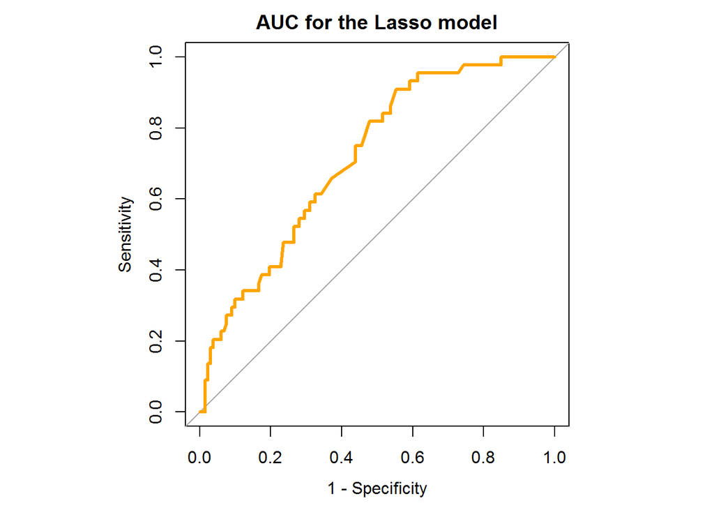

```r
plot.roc(roc(TBtest$trtfailure, predictionlasso), col = "orange", lwd = 3,
         main = "AUC for the Lasso model", xlab = "1 - Specificity", legacy.axes = TRUE)
```

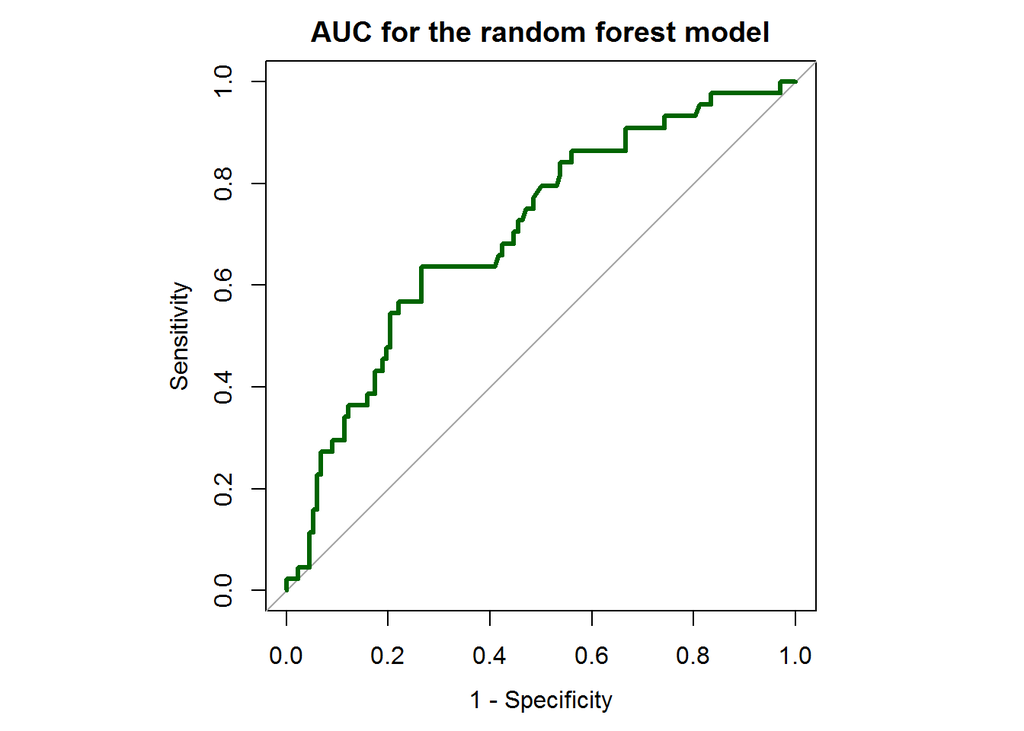

```r
plot.roc(roc(TBtest$trtfailure, predictionforest), col = "darkgreen", lwd = 3,
         main = "AUC for the random forest model", xlab = "1 - Specificity", legacy.axes = TRUE)
```

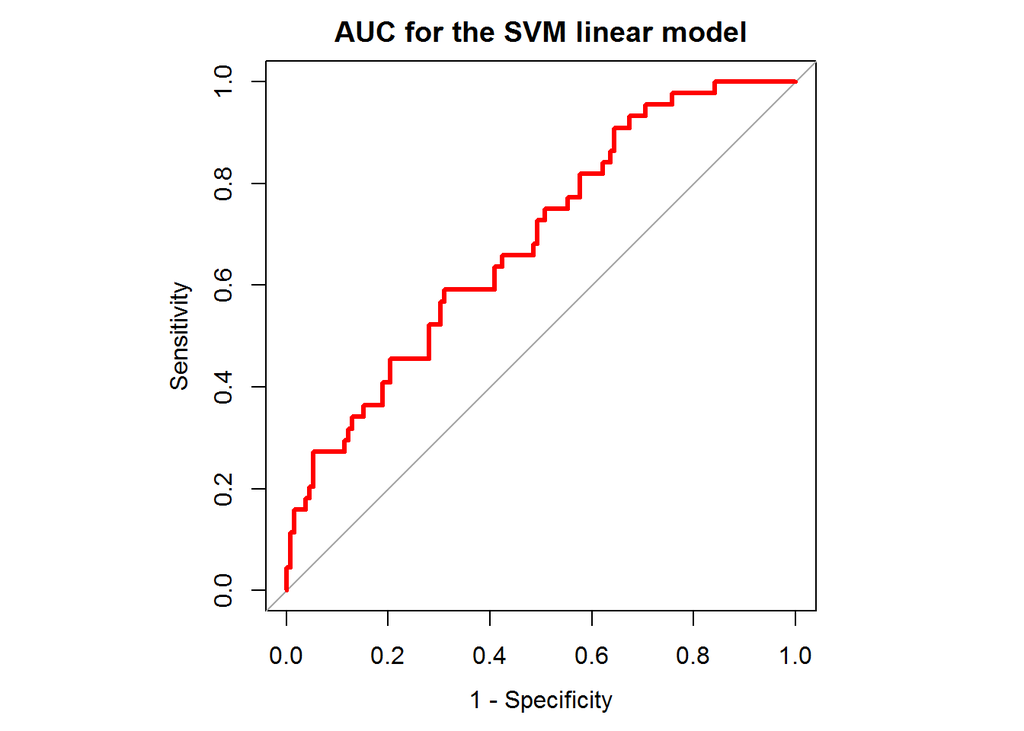

```r
plot.roc(roc(TBtest$trtfailure, predictionsvmlinear), col = "red", lwd = 3,
         main = "AUC for the SVM linear model", xlab = "1 - Specificity", legacy.axes = TRUE)
```

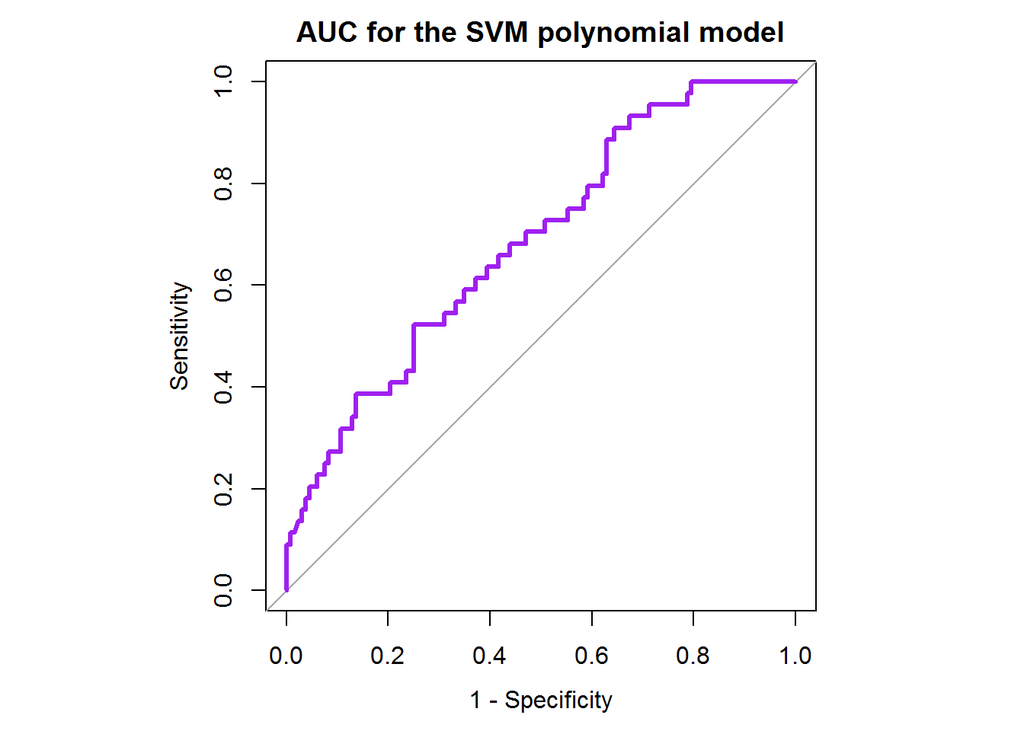

```r
plot.roc(roc(TBtest$trtfailure, predictionsvmpolynomial), col = "purple", lwd = 3,
         main = "AUC for the SVM polynomial model", xlab = "1 - Specificity", legacy.axes = TRUE)
```

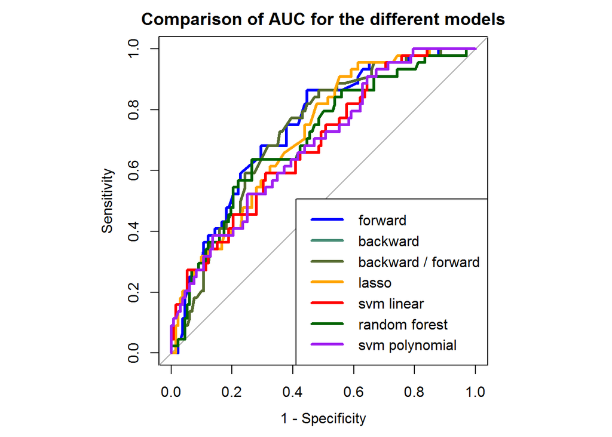

```r
par(pty="s")
plot.roc(roc(TBtest$trtfailure, predictionforward), col = "blue", lwd = 3,
         main = "Comparison of AUC for the different models", xlab = "1 - Specificity", legacy.axes = TRUE)
plot.roc(roc(TBtest$trtfailure, predictionbackward), add = TRUE,
         col = "aquamarine4", lwd = 3)
plot.roc(roc(TBtest$trtfailure, predictionboth), add = TRUE,
         col = "darkolivegreen", lwd = 3)
plot.roc(roc(TBtest$trtfailure, predictionlasso), add = TRUE,
         col = "orange", lwd = 3)
plot.roc(roc(TBtest$trtfailure, predictionforest), add = TRUE,
         col = "darkgreen", lwd = 3)
plot.roc(roc(TBtest$trtfailure, predictionsvmlinear), add = TRUE,
         col = "red", lwd = 3)
plot.roc(roc(TBtest$trtfailure, predictionsvmpolynomial), add = TRUE,
         col = "purple", lwd = 3)
legend(x = "bottomright", legend = c("forward", "backward", "backward / forward",
                                     "lasso", "svm linear", "random forest",
                                     "svm polynomial"),
       lty = c(1, 1, 1, 1, 1, 1, 1), lwd = c(3, 3, 3, 3, 3, 3, 3),
       col = c("blue", "aquamarine4", "darkolivegreen", "orange", "red", "darkgreen", "purple"))
```

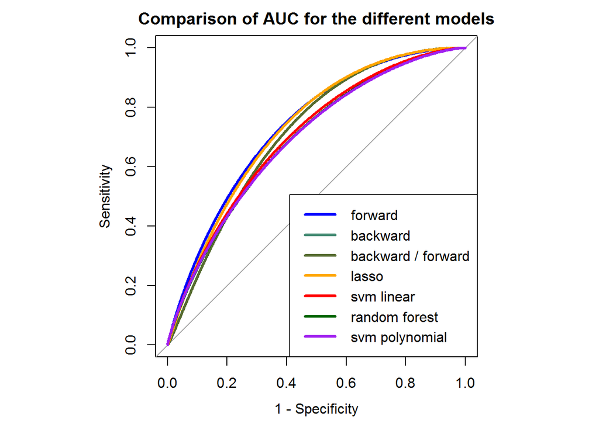

```r
## Area under the curve graph smoothed
par(pty="s")
plot.roc(smooth(roc(TBtest$trtfailure, predictionforward)), col = "blue", lwd = 3,
         main = "Comparison of AUC for the different models", xlab = "1 - Specificity", legacy.axes = TRUE)
plot.roc(smooth(roc(TBtest$trtfailure, predictionbackward)), add = TRUE,
         col = "aquamarine4", lwd = 3)
plot.roc(smooth(roc(TBtest$trtfailure, predictionboth)), add = TRUE,
         col = "darkolivegreen", lwd = 3)
plot.roc(smooth(roc(TBtest$trtfailure, predictionlasso)), add = TRUE,
         col = "orange", lwd = 3)
plot.roc(smooth(roc(TBtest$trtfailure, predictionforest)), add = TRUE,
         col = "darkgreen", lwd = 3)
plot.roc(smooth(roc(TBtest$trtfailure, predictionsvmlinear)), add = TRUE,
         col = "red", lwd = 3)
plot.roc(smooth(roc(TBtest$trtfailure, predictionsvmpolynomial)), add = TRUE,
         col = "purple", lwd = 3)
legend(x = "bottomright", legend = c("forward", "backward", "backward / forward",
                                     "lasso", "svm linear", "random forest",
                                     "svm polynomial"),
       lty = c(1, 1, 1, 1, 1, 1, 1), lwd = c(3, 3, 3, 3, 3, 3, 3),
       col = c("blue", "aquamarine4", "darkolivegreen", "orange", "red", "darkgreen", "purple"))
```

## IMPUTED DATABASE ANALYSIS

## Split the database into 70% training and 30% testing

The patients in the database are randomly split into 70% training set and 30% testing set. To keep results reproducible, I fix the seed to a fixed arbitrary number.

```r
# Set the seed to a fixed arbitrary number
set.seed(2)

# Divide data into train and test sets
sample <- sample.split(TBimputed$trtfailure, SplitRatio = 0.7)
TBimputedtrain <- subset(TBimputed, sample == TRUE)
TBimputedtest  <- subset(TBimputed, sample == FALSE)
```

## Basic demographics

Basic description of the dataset

```r
# Dimensions of the dataset
dim(TBimputed)
```

```
## [1] 643  26
```

```r
dim(TBimputedtrain)
```

```
## [1] 450  26
```

```r
dim(TBimputedtest)
```

```
## [1] 193  26
```

```r
# Distribution of treatment failure in the datasets
CrossTable(TBimputed$trtfailure)
```

```
##
##
##    Cell Contents
## |-------------------------|
## |                       N |
## |         N / Table Total |
## |-------------------------|
##
##
## Total Observations in Table:  643
##
##
##           |         0 |         1 |
##           |-----------|-----------|
##           |       491 |       152 |
##           |     0.764 |     0.236 |
##           |-----------|-----------|
##
##
##
##
```

```r
CrossTable(TBimputedtrain$trtfailure)
```

```
##
##
##    Cell Contents
## |-------------------------|
## |                       N |
## |         N / Table Total |
## |-------------------------|
##
##
## Total Observations in Table:  450
##
##
##           |         0 |         1 |
##           |-----------|-----------|
##           |       344 |       106 |
##           |     0.764 |     0.236 |
##           |-----------|-----------|
##
##
##
##
```

```r
CrossTable(TBimputedtest$trtfailure)
```

```
##
##
##    Cell Contents
## |-------------------------|
## |                       N |
## |         N / Table Total |
## |-------------------------|
##
##
## Total Observations in Table:  193
##
##
##           |         0 |         1 |
##           |-----------|-----------|
##           |       147 |        46 |
##           |     0.762 |     0.238 |
##           |-----------|-----------|
##
##
##
##
```

```r
# Age
summary(TBimputed$age_of_onset)
```

```
##    Min. 1st Qu.  Median    Mean 3rd Qu.    Max.
##   13.00   30.00   40.00   41.45   51.00   87.00
```

```r
summary(TBimputedtrain$age_of_onset)
```

```
##    Min. 1st Qu.  Median    Mean 3rd Qu.    Max.
##   13.00   29.00   39.50   40.84   50.00   84.00
```

```r
summary(TBimputedtest$age_of_onset)
```

```
##    Min. 1st Qu.  Median    Mean 3rd Qu.    Max.
##   16.00   32.00   43.00   42.87   53.00   87.00
```

```r
# Sex
CrossTable(TBimputed$gender)
```

```
##
##
##    Cell Contents
## |-------------------------|
## |                       N |
## |         N / Table Total |
## |-------------------------|
##
##
## Total Observations in Table:  643
##
##
##           |    female |      male |
##           |-----------|-----------|
##           |       203 |       440 |
##           |     0.316 |     0.684 |
##           |-----------|-----------|
##
##
##
##
```

```r
CrossTable(TBimputedtrain$gender)
```

```
##
##
##    Cell Contents
## |-------------------------|
## |                       N |
## |         N / Table Total |
## |-------------------------|
##
##
## Total Observations in Table:  450
##
##
##           |    female |      male |
##           |-----------|-----------|
##           |       145 |       305 |
##           |     0.322 |     0.678 |
##           |-----------|-----------|
##
##
##
##
```

```r
CrossTable(TBimputedtest$gender)
```

```
##
##
##    Cell Contents
## |-------------------------|
## |                       N |
## |         N / Table Total |
## |-------------------------|
##
##
## Total Observations in Table:  193
##
##
##           |    female |      male |
##           |-----------|-----------|
##           |        58 |       135 |
##           |     0.301 |     0.699 |
##           |-----------|-----------|
##
##
##
##
```

```r
# Country
CrossTable(TBimputed$country)
```

```
##
##
##    Cell Contents
## |-------------------------|
## |                       N |
## |         N / Table Total |
## |-------------------------|
##
##
## Total Observations in Table:  643
##
##
##            | azerbaijan |    belarus |    georgia |    moldova |    romania |
##            |------------|------------|------------|------------|------------|
##            |         60 |        413 |         60 |         18 |         92 |
##            |      0.093 |      0.642 |      0.093 |      0.028 |      0.143 |
##            |------------|------------|------------|------------|------------|
##
##
##
##
```

```r
CrossTable(TBimputedtrain$country)
```

```
##
##
##    Cell Contents
## |-------------------------|
## |                       N |
## |         N / Table Total |
## |-------------------------|
##
##
## Total Observations in Table:  450
##
##
##            | azerbaijan |    belarus |    georgia |    moldova |    romania |
##            |------------|------------|------------|------------|------------|
##            |         40 |        293 |         42 |         13 |         62 |
##            |      0.089 |      0.651 |      0.093 |      0.029 |      0.138 |
##            |------------|------------|------------|------------|------------|
##
##
##
##
```

```r
CrossTable(TBimputedtest$country)
```

```
##
##
##    Cell Contents
## |-------------------------|
## |                       N |
## |         N / Table Total |
## |-------------------------|
##
##
## Total Observations in Table:  193
##
##
##            | azerbaijan |    belarus |    georgia |    moldova |    romania |
##            |------------|------------|------------|------------|------------|
##            |         20 |        120 |         18 |          5 |         30 |
##            |      0.104 |      0.622 |      0.093 |      0.026 |      0.155 |
##            |------------|------------|------------|------------|------------|
##
##
##
##
```

## TRAINING PHASE: HERE I DEVELOP MODELS ONLY ON THE TRAINING SUBSET

## Forward stepwise selection

Automatic variable selection with forward stepwise selection starting with the empty model (model with no predictors). The criterion for selection is the Akaike Information Criterion (AIC), which rewards more predictive models but also penalizes more complex models to minimize overfitting.

```r
## Forward stepwise selection
forward <- stepAIC(glm(trtfailure ~ 1, family = binomial, data = TBimputedtrain),
                   scope = list(lower = ~ 1, upper = ~ country + age_of_onset + gender + education +
                                  employment + number_of_daily_contacts + type_of_resistance + bmi +
                                  lung_localization + x_ray_count + ct_count + dissemination +
                                  lungcavity_size + lungcavity_size + affect_pleura + shadow_pattern +
                                  pneumothorax + plevritis + nodicalcinatum + process_prevalence +
                                  lung_capacity_decrease + totalcavernum +
                                  culture + microscopy + social_risk_factors + regimen_drug), direction = "forward", trace = 0)
summary(forward)
```

```
##
## Call:
## glm(formula = trtfailure ~ lungcavity_size + employment + microscopy +
##     lung_localization + dissemination + country + type_of_resistance,
##     family = binomial, data = TBimputedtrain)
##
## Deviance Residuals:
##     Min       1Q   Median       3Q      Max
## -1.5443  -0.6551  -0.3534  -0.0001   3.2310
##
## Coefficients:
##                           Estimate Std. Error z value Pr(>|z|)
## (Intercept)              -15.82476 2774.65586  -0.006  0.99545
## lungcavity_size2          -0.60494    0.49038  -1.234  0.21735
## lungcavity_size3           0.70867    0.51586   1.374  0.16951
## lungcavity_size4          -0.25317    0.43828  -0.578  0.56351
## lungcavity_size5         -14.31625 2277.57932  -0.006  0.99498
## employment2               -0.55420    0.47218  -1.174  0.24051
## employment3                0.85435    1.39000   0.615  0.53879
## employment4               -0.30214    0.63536  -0.476  0.63440
## employment5              -16.90196  787.32941  -0.021  0.98287
## employment6                0.46989    0.47658   0.986  0.32415
## microscopy10to99in100     -1.36318    0.53547  -2.546  0.01090 *
## microscopy1to9in1         -0.46221    0.74315  -0.622  0.53397
## microscopy1to9in100       -0.30067    0.64110  -0.469  0.63908
## microscopymorethan99in1   16.64337 1890.16160   0.009  0.99297
## microscopynegative        -0.94089    0.55922  -1.682  0.09247 .
## lung_localization2        15.23103 2774.65546   0.005  0.99562
## lung_localization3        16.53009 2774.65547   0.006  0.99525
## dissemination2            13.48334 2277.57913   0.006  0.99528
## dissemination3            -1.13722    0.39328  -2.892  0.00383 **
## country2                   0.27174    1.10031   0.247  0.80493
## country3                   1.69295    1.13176   1.496  0.13469
## country4                  -0.20006    1.23232  -0.162  0.87103
## country5                  -1.97420    1.04906  -1.882  0.05985 .
## type_of_resistance2       -1.48874    1.11920  -1.330  0.18346
## type_of_resistance3        1.56263    1.75256   0.892  0.37259
## type_of_resistance4        0.06876    0.83383   0.082  0.93428
## type_of_resistance5       -0.92018    0.43021  -2.139  0.03244 *
## type_of_resistance6        0.42525    0.33215   1.280  0.20044
## ---
## Signif. codes:  0 '***' 0.001 '**' 0.01 '*' 0.05 '.' 0.1 ' ' 1
##
## (Dispersion parameter for binomial family taken to be 1)
##
##     Null deviance: 491.31  on 449  degrees of freedom
## Residual deviance: 360.19  on 422  degrees of freedom
## AIC: 416.19
##
## Number of Fisher Scoring iterations: 16
```

## Backward stepwise elimination

Automatic variable selection with backward stepwise selection starting with the full model (model with all predictors). The criterion for selection is the Akaike Information Criterion (AIC), which rewards more predictive models but also penalizes more complex models to minimize overfitting.

```r
## Backward selection
backward <- stepAIC(glm(trtfailure ~ ., family = binomial, data = TBimputedtrain),
                    scope = list(lower = ~ 1, upper = ~. + country + age_of_onset + gender + education +
                                  employment + number_of_daily_contacts + type_of_resistance + bmi +
                                  lung_localization + x_ray_count + ct_count + dissemination +
                                  lungcavity_size + lungcavity_size + affect_pleura + shadow_pattern +
                                  pneumothorax + plevritis + nodicalcinatum + process_prevalence +
                                  lung_capacity_decrease + totalcavernum +
                                  culture + microscopy + social_risk_factors + regimen_drug),
                    direction = "backward", trace = 0)
```

[output not shown]

[output not shown]

[output not shown]

[output not shown]

[output not shown]

[output not shown]

```r
summary(backward)
```

```
##
## Call:
## glm(formula = trtfailure ~ country + employment + type_of_resistance +
##     lung_localization + dissemination + lung_capacity_decrease +
##     microscopy, family = binomial, data = TBimputedtrain)
##
## Deviance Residuals:
##     Min       1Q   Median       3Q      Max
## -1.5922  -0.6801  -0.3776  -0.0001   3.2192
##
## Coefficients:
##                           Estimate Std. Error z value Pr(>|z|)
## (Intercept)              -15.93731 2775.83034  -0.006  0.99542
## country2                   0.40153    1.07706   0.373  0.70930
## country3                   1.81589    1.10886   1.638  0.10150
## country4                  -0.09122    1.22890  -0.074  0.94083
## country5                  -1.89127    1.04932  -1.802  0.07149 .
## employment2               -0.64613    0.45297  -1.426  0.15375
## employment3                0.64722    1.38599   0.467  0.64052
## employment4               -0.73255    0.61616  -1.189  0.23448
## employment5              -16.97314  788.32999  -0.022  0.98282
## employment6                0.31555    0.45536   0.693  0.48834
## type_of_resistance2       -1.49328    1.11179  -1.343  0.17923
## type_of_resistance3        1.73325    1.73337   1.000  0.31735
## type_of_resistance4       -0.10363    0.83250  -0.124  0.90093
## type_of_resistance5       -0.95474    0.42753  -2.233  0.02554 *
## type_of_resistance6        0.38734    0.32791   1.181  0.23750
## lung_localization2        15.13934 2775.82997   0.005  0.99565
## lung_localization3        16.54586 2775.82997   0.006  0.99524
## dissemination2            13.32572 3956.18042   0.003  0.99731
## dissemination3            -1.19373    0.38737  -3.082  0.00206 **
## lung_capacity_decrease2  -13.76047 3956.18051  -0.003  0.99722
## lung_capacity_decrease3    0.63669    0.30730   2.072  0.03827 *
## microscopy10to99in100     -1.41268    0.52540  -2.689  0.00717 **
## microscopy1to9in1         -0.62712    0.73307  -0.855  0.39229
## microscopy1to9in100       -0.41391    0.62735  -0.660  0.50939
## microscopymorethan99in1   16.40061 1892.79360   0.009  0.99309
## microscopynegative        -1.17471    0.53489  -2.196  0.02808 *
## ---
## Signif. codes:  0 '***' 0.001 '**' 0.01 '*' 0.05 '.' 0.1 ' ' 1
##
## (Dispersion parameter for binomial family taken to be 1)
##
##     Null deviance: 491.31  on 449  degrees of freedom
## Residual deviance: 363.53  on 424  degrees of freedom
## AIC: 415.53
##
## Number of Fisher Scoring iterations: 16
```

## Stepwise selection with both backward elimination and forward selection

Automatic variable selection with both backward elimination and forward selection starting with the full model (model with all predictors). The criterion for selection is the Akaike Information Criterion (AIC), which rewards more predictive models but also penalizes more complex models to minimize overfitting.

```r
## Both forward and backward
both <- stepAIC(glm(trtfailure ~ ., family = binomial, data = TBimputedtrain),
                scope = list(lower = ~ 1, upper = ~. + country + age_of_onset + gender + education +
                                  employment + number_of_daily_contacts + type_of_resistance + bmi +
                                  lung_localization + x_ray_count + ct_count + dissemination +
                                  lungcavity_size + lungcavity_size + affect_pleura + shadow_pattern +
                                  pneumothorax + plevritis + nodicalcinatum + process_prevalence +
                                  lung_capacity_decrease + totalcavernum +
                                  culture + microscopy + social_risk_factors + regimen_drug), direction = "both", trace = 0)
```

[output not shown]

[output not shown]

[output not shown]

[output not shown]

[output not shown]

[output not shown]

```r
summary(both)
```

```
##
## Call:
## glm(formula = trtfailure ~ country + employment + type_of_resistance +
##     lung_localization + dissemination + lung_capacity_decrease +
##     microscopy, family = binomial, data = TBimputedtrain)
##
## Deviance Residuals:
##     Min       1Q   Median       3Q      Max
## -1.5922  -0.6801  -0.3776  -0.0001   3.2192
##
## Coefficients:
##                           Estimate Std. Error z value Pr(>|z|)
## (Intercept)              -15.93731 2775.83034  -0.006  0.99542
## country2                   0.40153    1.07706   0.373  0.70930
## country3                   1.81589    1.10886   1.638  0.10150
## country4                  -0.09122    1.22890  -0.074  0.94083
## country5                  -1.89127    1.04932  -1.802  0.07149 .
## employment2               -0.64613    0.45297  -1.426  0.15375
## employment3                0.64722    1.38599   0.467  0.64052
## employment4               -0.73255    0.61616  -1.189  0.23448
## employment5              -16.97314  788.32999  -0.022  0.98282
## employment6                0.31555    0.45536   0.693  0.48834
## type_of_resistance2       -1.49328    1.11179  -1.343  0.17923
## type_of_resistance3        1.73325    1.73337   1.000  0.31735
## type_of_resistance4       -0.10363    0.83250  -0.124  0.90093
## type_of_resistance5       -0.95474    0.42753  -2.233  0.02554 *
## type_of_resistance6        0.38734    0.32791   1.181  0.23750
## lung_localization2        15.13934 2775.82997   0.005  0.99565
## lung_localization3        16.54586 2775.82997   0.006  0.99524
## dissemination2            13.32572 3956.18042   0.003  0.99731
## dissemination3            -1.19373    0.38737  -3.082  0.00206 **
## lung_capacity_decrease2  -13.76047 3956.18051  -0.003  0.99722
## lung_capacity_decrease3    0.63669    0.30730   2.072  0.03827 *
## microscopy10to99in100     -1.41268    0.52540  -2.689  0.00717 **
## microscopy1to9in1         -0.62712    0.73307  -0.855  0.39229
## microscopy1to9in100       -0.41391    0.62735  -0.660  0.50939
## microscopymorethan99in1   16.40061 1892.79360   0.009  0.99309
## microscopynegative        -1.17471    0.53489  -2.196  0.02808 *
## ---
## Signif. codes:  0 '***' 0.001 '**' 0.01 '*' 0.05 '.' 0.1 ' ' 1
##
## (Dispersion parameter for binomial family taken to be 1)
##
##     Null deviance: 491.31  on 449  degrees of freedom
## Residual deviance: 363.53  on 424  degrees of freedom
## AIC: 415.53
##
## Number of Fisher Scoring iterations: 16
```

## Lasso

The Lasso model puts a penalty for more complex models and shrinks predictors with coefficients close to 0 to being 0. Therefore, the resulting model is sparse (has as few predictors as possible while maintaining a good predictive power) and, therefore, more interpretable.

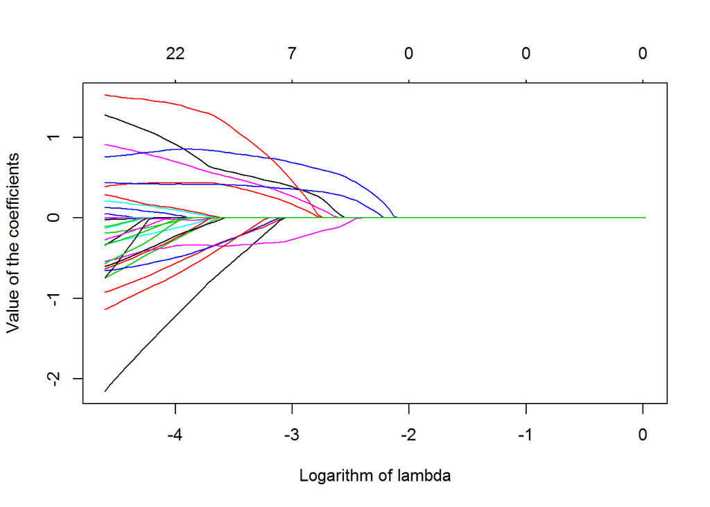

```r
## Create the x matrix
x <- model.matrix(trtfailure ~ ., data = TBimputedtrain)[ , -which(names(TBimputedtrain) %in% "trtfailure")]

## Create the y vector
y <- TBimputedtrain$trtfailure

## Create a grid of lambda values
grid <- 10 ^ seq(0.01, -2, length = 100)

## Fit the Lasso model with unknown value for lambda
lassogrid <- glmnet(x, y, family = "binomial", alpha = 1, lambda = grid,
                    standardize = TRUE)
plot(lassogrid, xvar="lambda", xlab = "Logarithm of lambda",
     ylab = "Value of the coefficients")
```

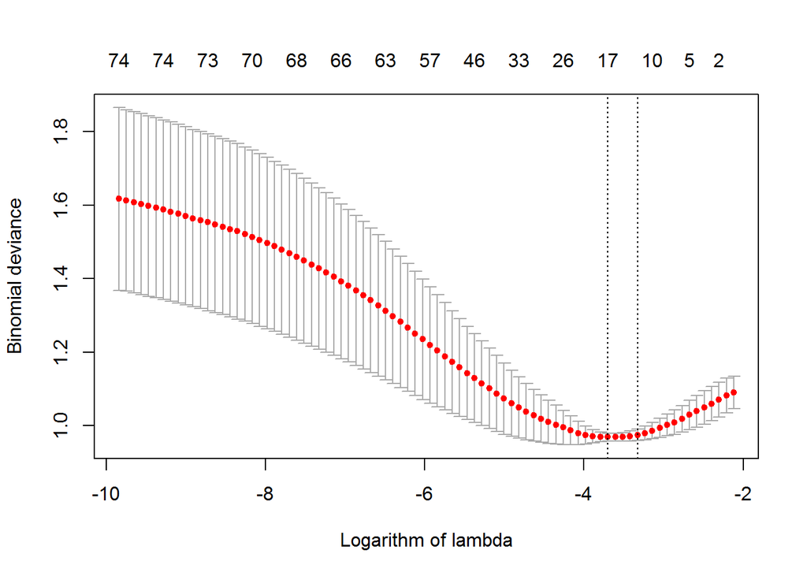

```r
## Set a seed with an arbitrary number
set.seed(11)

## Calculate the best value for lambda using cross validation
cvlasso <- cv.glmnet(x, y, family = "binomial", alpha = 1, nfold = 3)
plot(cvlasso, xlab = "Logarithm of lambda", ylab = "Binomial deviance")
```

```r
## Determine the best lambda value
bestlambda <- cvlasso$lambda.min
bestlambda
```

```
## [1] 0.02471387
```

```r
## Fit the Lasso model with the lambda value that minimizes error (deviance)
lasso <- glmnet(x, y, family = "binomial", alpha = 1, lambda = bestlambda,
                standardize = TRUE)

## Lasso model
lassocoefficients <- predict (lasso, type = "coefficients", s = bestlambda)
lassocoefficients
```

```
## 81 x 1 sparse Matrix of class "dgCMatrix"
##                                     1
## (Intercept)              -1.677886432
## country2                  .
## country3                  0.633016441
## country4                  .
## country5                 -0.356526420
## age_of_onset              .
## gender2                   .
## education2                .
## education3                .
## education4                .
## education5                .
## employment2              -0.012472516
## employment3               .
## employment4               .
## employment5              -0.784100573
## employment6               0.438268263
## number_of_daily_contacts  .
## type_of_resistance2      -0.049259657
## type_of_resistance3       .
## type_of_resistance4       .
## type_of_resistance5      -0.360467775
## type_of_resistance6       0.016950672
## bmi                       .
## lung_localization2        .
## lung_localization3        0.565464267
## x_ray_count               .
## ct_count                  .
## dissemination2            .
## dissemination3            .
## lungcavity_size2          .
## lungcavity_size3          0.841861169
## lungcavity_size4          .
## lungcavity_size5          .
## affect_pleura2            .
## affect_pleura3            .
## shadow_pattern2           .
## shadow_pattern3           .
## shadow_pattern4           .
```

[output cut: 28 more lines]

```
## social_risk_factors2      .
## social_risk_factors3      .
## social_risk_factors4      .
## social_risk_factors5      .
## social_risk_factors6     -0.004324884
## social_risk_factors7      .
## social_risk_factors8      .
## regimen_drug2             .
## regimen_drug3             .
## regimen_drug4            -0.452753694
## regimen_drug5             .
## regimen_drug6             .
## regimen_drug7             .
## regimen_drug8             .
## regimen_drug9             .
```

```r
## Sparse LASSO model
lassosparse <- glmnet(x, y, family = "binomial", alpha = 1, lambda = cvlasso$lambda.1se,
                standardize = TRUE)

## Lasso model
lassosparsecoefficients <- predict (lassosparse, type = "coefficients", s = cvlasso$lambda.1se)
lassosparsecoefficients
```

```
## 81 x 1 sparse Matrix of class "dgCMatrix"
##                                   1
## (Intercept)              -1.6277148
## country2                  .
## country3                  0.5067699
## country4                  .
## country5                 -0.1558263
## age_of_onset              .
## gender2                   .
## education2                .
## education3                .
## education4                .
## education5                .
## employment2               .
## employment3               .
## employment4               .
## employment5              -0.3168124
## employment6               0.3256175
## number_of_daily_contacts  .
## type_of_resistance2       .
## type_of_resistance3       .
## type_of_resistance4       .
## type_of_resistance5      -0.1401138
## type_of_resistance6       .
## bmi                       .
## lung_localization2        .
## lung_localization3        0.4315506
## x_ray_count               .
## ct_count                  .
## dissemination2            .
## dissemination3            .
## lungcavity_size2          .
## lungcavity_size3          0.7694334
## lungcavity_size4          .
## lungcavity_size5          .
## affect_pleura2            .
## affect_pleura3            .
## shadow_pattern2           .
## shadow_pattern3           .
## shadow_pattern4           .
```

[output cut: 28 more lines]

```
## social_risk_factors2      .
## social_risk_factors3      .
## social_risk_factors4      .
## social_risk_factors5      .
## social_risk_factors6      .
## social_risk_factors7      .
## social_risk_factors8      .
## regimen_drug2             .
## regimen_drug3             .
## regimen_drug4            -0.0996183
## regimen_drug5             .
## regimen_drug6             .
## regimen_drug7             .
## regimen_drug8             .
## regimen_drug9             .
```

## Random forests

Random forests fit several decorrelated decision trees to the data and “average” them so that the resulting model has as little bias and as little variance as possible. Decorrelated trees refer to the fact that in each decision node the variables to perform the next branch of each tree are only a subset of number mtry of the available variables ensuring that the individual trees are heterogeneous and capture the variability in the data.

```r
## Set a seed with an arbitrary number
set.seed(23)

## Divide the training set into 3 folds
folds <- sample(rep(1:3, length = nrow(TBimputedtrain)))

## Make sure folds have more or less the same size
table(folds)
```

```
## folds
##   1   2   3
## 150 150 150
```

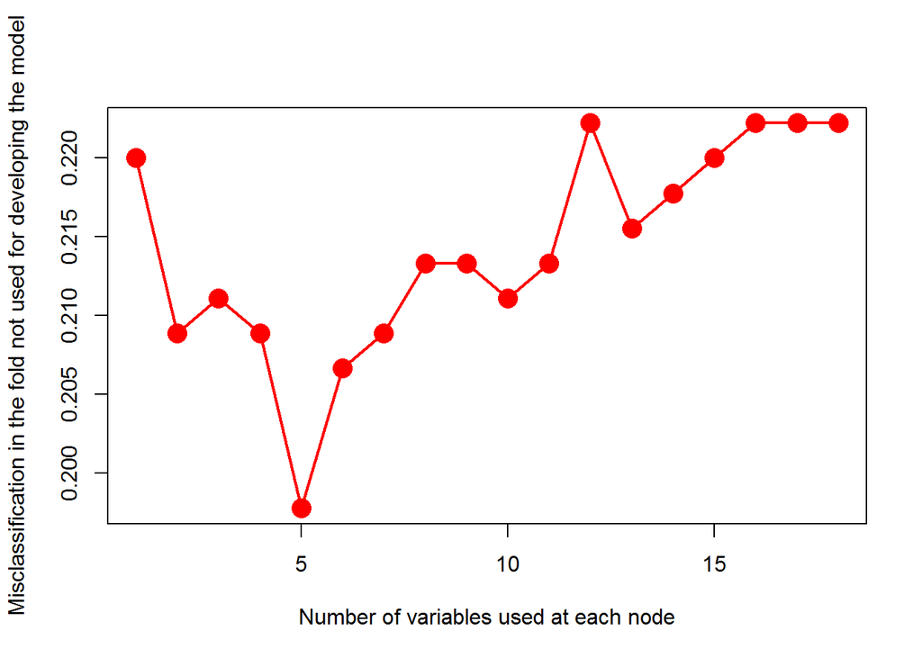

```r
## Find the random forest model with best mtry (number of variables
##considered in each decision node)
## Vector with different values for mtry from 1 to 19 (number of variables)
mtryvalues <- 1:18

## Set a seed with an arbitrary number
set.seed(9)

## Set an empty data frame with the proportion misclassified
##(rows will be different mtry, and columns values of k)
proportionerror <- data.frame(matrix(0, ncol = 3, nrow = 18))
colnames(proportionerror) <- c("k = 1", "k = 2", "k = 3")

## Calculate the best mtry by cross-validation
## Create a loop with 3 folds
for (k in 1 : 3) {
  ## Create a loop with 18 values of mtry
for (j in 1 : 18) {
  ## Calculate the random forest model based on 2 of the folds
forest <- randomForest(trtfailure ~ ., data = TBimputedtrain[folds != k, ],
                       mtry = mtryvalues[j], ntree = 1000, importance = TRUE)
## Predict performance on the remaining fold not used for fitting the model
prediction <- predict(forest, newdata = TBimputedtrain[folds == k,
                                                       - which(names(TBimputedtrain) == "trtfailure")])
## Confusion matrix for the prediction
confusionmatrix <- table(prediction, TBimputedtrain[folds
                                                    == k, which(names(TBimputedtrain) == "trtfailure")])
## Misclassification error
proportionerror[j, k] <- (confusionmatrix[2, 1] + confusionmatrix[1, 2]) /
  (confusionmatrix[1, 1] + confusionmatrix[1, 2] +
     confusionmatrix[2, 1] + confusionmatrix[2, 2])
}
}

## Calculate the mean prediction error for each mtry
proportionerror$meanerror <- rowMeans(proportionerror)

## Plot the proportion of errors in relation with the number of variables in mtry
plot(mtryvalues, proportionerror$meanerror, pch = 16, cex = 2,
     col = "red", type = "o", lwd = 2,
     xlab = "Number of variables used at each node",
     ylab = "Misclassification in the fold not used for developing the model")
```

```r
## Identify the lowest mtry within 1 standard error of the mtry with minimum error
mtryminimumerror <- which(proportionerror$meanerror
                          == min(proportionerror$meanerror))[1]

## Calculate the definitive random forest in the full training set with the minimum error value of mtry
forest <- randomForest(trtfailure ~ ., data = TBimputedtrain,
                       mtry = mtryminimumerror, ntree = 1000, importance = TRUE)
forest
```

```
##
## Call:
##  randomForest(formula = trtfailure ~ ., data = TBimputedtrain,      mtry = mtryminimumerror, ntree = 1000, importance = TRUE)
##                Type of random forest: classification
##                      Number of trees: 1000
## No. of variables tried at each split: 5
##
##         OOB estimate of  error rate: 20.89%
## Confusion matrix:
##     0  1 class.error
## 0 326 18  0.05232558
## 1  76 30  0.71698113
```

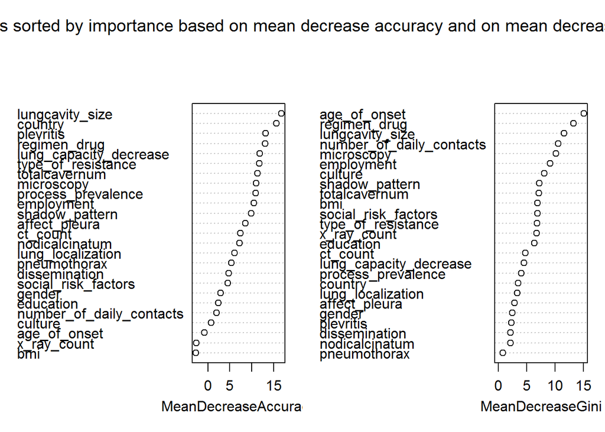

```r
varImpPlot(forest, main =
             "Variables sorted by importance based on mean decrease accuracy and on mean decreased Gini")
```

## Support vector machines: linear kernel

Support vector machines divide the observations by creating a boundary between the classes. As the observations might not be separable in their original dimension space, support vector machines separate the observations in a higher dimensional space that is visited through a kernel.

```r
## Set a seed with an arbitrary number
set.seed(33)

## Support vector machine with a radial kernel tune best model using 3 fold cross-validation
svmparameterslinear <- tune(svm, trtfailure ~ ., data = TBimputedtrain,
                            kernel = "linear",
                            ranges = list(cost = seq(0.01, 2, 0.05)),
                      tunecontrol = tune.control(cross = 3),
                      scale = TRUE, probability = TRUE)

## Parameters for the best model
svmparameterslinear
```

```
##
## Parameter tuning of 'svm':
##
## - sampling method: 3-fold cross validation
##
## - best parameters:
##  cost
##  0.11
##
## - best performance: 0.2
```

```r
## Select the best model
svmlinear <- svmparameterslinear$best.model
svmlinear
```

```
##
## Call:
## best.tune(method = svm, train.x = trtfailure ~ ., data = TBimputedtrain,
##     ranges = list(cost = seq(0.01, 2, 0.05)), tunecontrol = tune.control(cross = 3),
##     kernel = "linear", scale = TRUE, probability = TRUE)
##
##
## Parameters:
##    SVM-Type:  C-classification
##  SVM-Kernel:  linear
##        cost:  0.11
##       gamma:  0.01234568
##
## Number of Support Vectors:  222
```

## Support vector machines: polynomial kernel

```r
## Set a seed with an arbitrary number
set.seed(52)

## Support vector machine with a polynomial kernel tune best model using 3 fold cross-validation
svmparameterspolynomial <- tune(svm, trtfailure ~ ., data = TBimputedtrain,
                            kernel = "polynomial",
                            ranges = list(cost = seq(0.01, 2, 0.05),
                                          degree = seq(1, 6, 1)),
                      tunecontrol = tune.control(cross = 3),
                      scale = TRUE, probability = TRUE)

## Parameters for the best model
svmparameterspolynomial
```

```
##
## Parameter tuning of 'svm':
##
## - sampling method: 3-fold cross validation
##
## - best parameters:
##  cost degree
##  0.01      1
##
## - best performance: 0.2355556
```

```r
## Select the best model
svmpolynomial <- svmparameterspolynomial$best.model
svmpolynomial
```

```
##
## Call:
## best.tune(method = svm, train.x = trtfailure ~ ., data = TBimputedtrain,
##     ranges = list(cost = seq(0.01, 2, 0.05), degree = seq(1,
##         6, 1)), tunecontrol = tune.control(cross = 3), kernel = "polynomial",
##     scale = TRUE, probability = TRUE)
##
##
## Parameters:
##    SVM-Type:  C-classification
##  SVM-Kernel:  polynomial
##        cost:  0.01
##      degree:  1
##       gamma:  0.01234568
##      coef.0:  0
##
## Number of Support Vectors:  220
```

## TESTING THE PERFORMANCE OF THE DIFFERENT METHODS IN THE TESTING SET

## Forward stepwise selection

```r
## Prediction based on area under the curve
predictionforward <- predict(forward, type = "response",
                             newdata = TBimputedtest[ , - which(names(TBimputedtest) == "trtfailure")])
aucforward <- auc(TBimputedtest$trtfailure, predictionforward)
aucforward
```

```
## Area under the curve: 0.7686
```

```r
ciforward <- ci.auc(TBimputedtest$trtfailure, predictionforward)
ciforward
```

```
## 95% CI: 0.6923-0.8448 (DeLong)
```

```r
## Prediction based on misclassification error
predictionforward01 <- ifelse(predictionforward > 0.5, 1, 0)
predictionforward01 <- as.factor(predictionforward01)
confusionmatrix <- table(predictionforward01,
                         TBimputedtest[ , which(names(TBimputedtest) == "trtfailure")])
misclassificationforward <- (confusionmatrix[2, 1] + confusionmatrix[1, 2]) /
  (confusionmatrix[1, 1] + confusionmatrix[1, 2] + confusionmatrix[2, 1] + confusionmatrix[2, 2])
misclassificationforward
```

```
## [1] 0.2279793
```

```r
## Prediction based on sensitivity, specificity, positive predictive value,
##and negative predictive value
sensitivityforward <- confusionmatrix[2, 2] /
  (confusionmatrix[1, 2] + confusionmatrix[2, 2])
sensitivityforward
```

```
## [1] 0.2826087
```

```r
specificityforward <- confusionmatrix[1, 1] /
  (confusionmatrix[1, 1] + confusionmatrix[2, 1])
specificityforward
```

```
## [1] 0.9251701
```

```r
ppvforward <- confusionmatrix[2, 2] /
  (confusionmatrix[2, 1] + confusionmatrix[2, 2])
ppvforward
```

```
## [1] 0.5416667
```

```r
npvforward <- confusionmatrix[1, 1] /
  (confusionmatrix[1, 1] + confusionmatrix[1, 2])
npvforward
```

```
## [1] 0.8047337
```

```r
## Calculate optimal threshold with Youden's index
rocforward <- roc(TBimputedtest$trtfailure, predictionforward)
bestforward <- coords(rocforward, "b", ret = "threshold", best.method = "youden")
bestforward
```

```
## [1] 0.2393352
```

```r
## Prediction based on misclassification error
predictionforwardyouden01 <- ifelse(predictionforward > bestforward, 1, 0)
predictionforwardyouden01 <- as.factor(predictionforwardyouden01)
confusionmatrix <- table(predictionforwardyouden01,
                         TBimputedtest[ , which(names(TBimputedtest) == "trtfailure")])
misclassificationforwardyouden <- (confusionmatrix[2, 1] + confusionmatrix[1, 2]) /
  (confusionmatrix[1, 1] + confusionmatrix[1, 2] + confusionmatrix[2, 1] + confusionmatrix[2, 2])
misclassificationforwardyouden
```

```
## [1] 0.2590674
```

```r
## Prediction based on sensitivity, specificity, positive predictive value,
##and negative predictive value
sensitivityforwardyouden <- confusionmatrix[2, 2] /
  (confusionmatrix[1, 2] + confusionmatrix[2, 2])
sensitivityforwardyouden
```

```
## [1] 0.7391304
```

```r
specificityforwardyouden <- confusionmatrix[1, 1] /
  (confusionmatrix[1, 1] + confusionmatrix[2, 1])
specificityforwardyouden
```

```
## [1] 0.7414966
```

```r
ppvforwardyouden <- confusionmatrix[2, 2] /
  (confusionmatrix[2, 1] + confusionmatrix[2, 2])
ppvforwardyouden
```

```
## [1] 0.4722222
```

```r
npvforwardyouden <- confusionmatrix[1, 1] /
  (confusionmatrix[1, 1] + confusionmatrix[1, 2])
npvforwardyouden
```

```
## [1] 0.9008264
```

## Backward stepwise elimination

```r
## Prediction based on area under the curve
predictionbackward <- predict(backward, type = "response",
                              newdata = TBimputedtest[ , - which(names(TBimputedtest) == "trtfailure")])
aucbackward <- auc(TBimputedtest$trtfailure, predictionbackward)
aucbackward
```

```
## Area under the curve: 0.7516
```

```r
cibackward <- ci.auc(TBimputedtest$trtfailure, predictionbackward)
cibackward
```

```
## 95% CI: 0.6727-0.8304 (DeLong)
```

```r
## Prediction based on misclassification error
predictionbackward01 <- ifelse(predictionbackward > 0.5, 1, 0)
predictionbackward01 <- as.factor(predictionbackward01)
confusionmatrix <- table(predictionbackward01,
                         TBimputedtest[ , which(names(TBimputedtest) == "trtfailure")])
misclassificationbackward <- (confusionmatrix[2, 1] + confusionmatrix[1, 2]) /
  (confusionmatrix[1, 1] + confusionmatrix[1, 2] + confusionmatrix[2, 1] + confusionmatrix[2, 2])
misclassificationbackward
```

```
## [1] 0.2331606
```

```r
## Prediction based on sensitivity, specificity, positive predictive value,
##and negative predictive value
sensitivitybackward <- confusionmatrix[2, 2] /
  (confusionmatrix[1, 2] + confusionmatrix[2, 2])
sensitivitybackward
```

```
## [1] 0.3043478
```

```r
specificitybackward <- confusionmatrix[1, 1] /
  (confusionmatrix[1, 1] + confusionmatrix[2, 1])
specificitybackward
```

```
## [1] 0.9115646
```

```r
ppvbackward <- confusionmatrix[2, 2] /
  (confusionmatrix[2, 1] + confusionmatrix[2, 2])
ppvbackward
```

```
## [1] 0.5185185
```

```r
npvbackward <- confusionmatrix[1, 1] /
  (confusionmatrix[1, 1] + confusionmatrix[1, 2])
npvbackward
```

```
## [1] 0.8072289
```

```r
## Calculate optimal threshold with Youden's index
rocbackward <- roc(TBimputedtest$trtfailure, predictionbackward)
besTBimputedackward <- coords(rocbackward, "b", ret = "threshold", best.method = "youden")
besTBimputedackward
```

```
## [1] 0.1895058
```

```r
## Prediction based on misclassification error
predictionbackwardyouden01 <- ifelse(predictionbackward > besTBimputedackward, 1, 0)
predictionbackwardyouden01 <- as.factor(predictionbackwardyouden01)
confusionmatrix <- table(predictionbackwardyouden01,
                         TBimputedtest[ , which(names(TBimputedtest) == "trtfailure")])
misclassificationbackwardyouden <- (confusionmatrix[2, 1] + confusionmatrix[1, 2]) /
  (confusionmatrix[1, 1] + confusionmatrix[1, 2] + confusionmatrix[2, 1] + confusionmatrix[2, 2])
misclassificationbackwardyouden
```

```
## [1] 0.2953368
```

```r
## Prediction based on sensitivity, specificity, positive predictive value,
##and negative predictive value
sensitivitybackwardyouden <- confusionmatrix[2, 2] /
  (confusionmatrix[1, 2] + confusionmatrix[2, 2])
sensitivitybackwardyouden
```

```
## [1] 0.8043478
```

```r
specificitybackwardyouden <- confusionmatrix[1, 1] /
  (confusionmatrix[1, 1] + confusionmatrix[2, 1])
specificitybackwardyouden
```

```
## [1] 0.6734694
```

```r
ppvbackwardyouden <- confusionmatrix[2, 2] /
  (confusionmatrix[2, 1] + confusionmatrix[2, 2])
ppvbackwardyouden
```

```
## [1] 0.4352941
```

```r
npvbackwardyouden <- confusionmatrix[1, 1] /
  (confusionmatrix[1, 1] + confusionmatrix[1, 2])
npvbackwardyouden
```

```
## [1] 0.9166667
```

## Stepwise selection with both backward elimination and forward selection

```r
## Prediction based on area under the curve
predictionboth <- predict(both, type = "response", newdata =
                            TBimputedtest[ , - which(names(TBimputedtest) == "trtfailure")])
aucboth <- auc(TBimputedtest$trtfailure, predictionboth)
aucboth
```

```
## Area under the curve: 0.7516
```

```r
ciboth <- ci.auc(TBimputedtest$trtfailure, predictionboth)
ciboth
```

```
## 95% CI: 0.6727-0.8304 (DeLong)
```

```r
## Prediction based on misclassification error
predictionboth01 <- ifelse(predictionboth > 0.5, 1, 0)
predictionboth01 <- as.factor(predictionboth01)
confusionmatrix <- table(predictionboth01,
                         TBimputedtest[ , which(names(TBimputedtest) == "trtfailure")])
misclassificationboth <- (confusionmatrix[2, 1] + confusionmatrix[1, 2]) /
  (confusionmatrix[1, 1] + confusionmatrix[1, 2] + confusionmatrix[2, 1] + confusionmatrix[2, 2])
misclassificationboth
```

```
## [1] 0.2331606
```

```r
## Prediction based on sensitivity, specificity, positive predictive value,
##and negative predictive value
sensitivityboth <- confusionmatrix[2, 2] /
  (confusionmatrix[1, 2] + confusionmatrix[2, 2])
sensitivityboth
```

```
## [1] 0.3043478
```

```r
specificityboth <- confusionmatrix[1, 1] /
  (confusionmatrix[1, 1] + confusionmatrix[2, 1])
specificityboth
```

```
## [1] 0.9115646
```

```r
ppvboth <- confusionmatrix[2, 2] /
  (confusionmatrix[2, 1] + confusionmatrix[2, 2])
ppvboth
```

```
## [1] 0.5185185
```

```r
npvboth <- confusionmatrix[1, 1] /
  (confusionmatrix[1, 1] + confusionmatrix[1, 2])
npvboth
```

```
## [1] 0.8072289
```

```r
## Calculate optimal threshold with Youden's index
rocboth <- roc(TBimputedtest$trtfailure, predictionboth)
besTBimputedoth <- coords(rocboth, "b", ret = "threshold", best.method = "youden")
besTBimputedoth
```

```
## [1] 0.1895058
```

```r
## Prediction based on misclassification error
predictionbothyouden01 <- ifelse(predictionboth > besTBimputedoth, 1, 0)
predictionbothyouden01 <- as.factor(predictionbothyouden01)
confusionmatrix <- table(predictionbothyouden01,
                         TBimputedtest[ , which(names(TBimputedtest) == "trtfailure")])
misclassificationbothyouden <- (confusionmatrix[2, 1] + confusionmatrix[1, 2]) /
  (confusionmatrix[1, 1] + confusionmatrix[1, 2] + confusionmatrix[2, 1] + confusionmatrix[2, 2])
misclassificationbothyouden
```

```
## [1] 0.2953368
```

```r
## Prediction based on sensitivity, specificity, positive predictive value,
##and negative predictive value
sensitivitybothyouden <- confusionmatrix[2, 2] /
  (confusionmatrix[1, 2] + confusionmatrix[2, 2])
sensitivitybothyouden
```

```
## [1] 0.8043478
```

```r
specificitybothyouden <- confusionmatrix[1, 1] /
  (confusionmatrix[1, 1] + confusionmatrix[2, 1])
specificitybothyouden
```

```
## [1] 0.6734694
```

```r
ppvbothyouden <- confusionmatrix[2, 2] /
  (confusionmatrix[2, 1] + confusionmatrix[2, 2])
ppvbothyouden
```

```
## [1] 0.4352941
```

```r
npvbothyouden <- confusionmatrix[1, 1] /
  (confusionmatrix[1, 1] + confusionmatrix[1, 2])
npvbothyouden
```

```
## [1] 0.9166667
```

## Lasso

```r
## Prediction based on area under the curve
## Create the x matrix
x <- model.matrix(trtfailure ~ ., data = TBimputedtest)[ , -which(names(TBimputedtest) %in% "trtfailure")]
## Create the y vector
y <- TBimputedtest$trtfailure
## Lasso predictions
predictionlasso <- predict(lasso, newx = x, type = "response")
predictionlasso <- as.numeric(predictionlasso)
## Area under the curve
auclasso <- auc(TBimputedtest$trtfailure, predictionlasso)
auclasso
```

```
## Area under the curve: 0.7335
```

```r
cilasso <- ci.auc(TBimputedtest$trtfailure, predictionlasso)
cilasso
```

```
## 95% CI: 0.6524-0.8147 (DeLong)
```

```r
## Prediction based on misclassification error
predictionlasso01 <- ifelse(predictionlasso > 0.5, 1, 0)
predictionlasso01 <- as.factor(predictionlasso01)
confusionmatrix <- table(predictionlasso01,
                         TBimputedtest[ , which(names(TBimputedtest) == "trtfailure")])
misclassificationlasso <- (confusionmatrix[2, 1] + confusionmatrix[1, 2]) /
  (confusionmatrix[1, 1] + confusionmatrix[1, 2] + confusionmatrix[2, 1] + confusionmatrix[2, 2])
misclassificationlasso
```

```
## [1] 0.2435233
```

```r
## Prediction based on sensitivity, specificity, positive predictive value,
##and negative predictive value
sensitivitylasso <- confusionmatrix[2, 2] /
  (confusionmatrix[1, 2] + confusionmatrix[2, 2])
sensitivitylasso
```

```
## [1] 0.1086957
```

```r
specificitylasso <- confusionmatrix[1, 1] /
  (confusionmatrix[1, 1] + confusionmatrix[2, 1])
specificitylasso
```

```
## [1] 0.9591837
```

```r
ppvlasso <- confusionmatrix[2, 2] /
  (confusionmatrix[2, 1] + confusionmatrix[2, 2])
ppvlasso
```

```
## [1] 0.4545455
```

```r
npvlasso <- confusionmatrix[1, 1] /
  (confusionmatrix[1, 1] + confusionmatrix[1, 2])
npvlasso
```

```
## [1] 0.7747253
```

```r
## Calculate optimal threshold with Youden's index
roclasso <- roc(TBimputedtest$trtfailure, predictionlasso)
bestlasso <- coords(roclasso, "b", ret = "threshold", best.method = "youden")
bestlasso
```

```
## [1] 0.2447048
```

```r
## Prediction based on misclassification error
predictionlassoyouden01 <- ifelse(predictionlasso > bestlasso, 1, 0)
predictionlassoyouden01 <- as.factor(predictionlassoyouden01)
confusionmatrix <- table(predictionlassoyouden01,
                         TBimputedtest[ , which(names(TBimputedtest) == "trtfailure")])
misclassificationlassoyouden <- (confusionmatrix[2, 1] + confusionmatrix[1, 2]) /
  (confusionmatrix[1, 1] + confusionmatrix[1, 2] + confusionmatrix[2, 1] + confusionmatrix[2, 2])
misclassificationlassoyouden
```

```
## [1] 0.2849741
```

```r
## Prediction based on sensitivity, specificity, positive predictive value,
##and negative predictive value
sensitivitylassoyouden <- confusionmatrix[2, 2] /
  (confusionmatrix[1, 2] + confusionmatrix[2, 2])
sensitivitylassoyouden
```

```
## [1] 0.673913
```

```r
specificitylassoyouden <- confusionmatrix[1, 1] /
  (confusionmatrix[1, 1] + confusionmatrix[2, 1])
specificitylassoyouden
```

```
## [1] 0.7278912
```

```r
ppvlassoyouden <- confusionmatrix[2, 2] /
  (confusionmatrix[2, 1] + confusionmatrix[2, 2])
ppvlassoyouden
```

```
## [1] 0.4366197
```

```r
npvlassoyouden <- confusionmatrix[1, 1] /
  (confusionmatrix[1, 1] + confusionmatrix[1, 2])
npvlassoyouden
```

```
## [1] 0.8770492
```

## Random Forests

```r
## Prediction based on area under the curve
predictionforest <- predict(forest, type = "prob", newdata =
                              TBimputedtest[ , - which(names(TBimputedtest) == "trtfailure")])[ , 2]
aucforest <- auc(TBimputedtest$trtfailure, predictionforest)
aucforest
```

```
## Area under the curve: 0.7286
```

```r
ciforest <- ci.auc(TBimputedtest$trtfailure, predictionforest)
ciforest
```

```
## 95% CI: 0.6454-0.8118 (DeLong)
```

```r
## Prediction based on misclassification error
predictionforest01 <- predict(forest,
                              newdata = TBimputedtest[ , - which(names(TBimputedtest) == "trtfailure")])
confusionmatrix <- table(predictionforest01,
                         TBimputedtest[ , which(names(TBimputedtest) == "trtfailure")])
misclassificationforest <- (confusionmatrix[2, 1] + confusionmatrix[1, 2]) /
  (confusionmatrix[1, 1] + confusionmatrix[1, 2] + confusionmatrix[2, 1] + confusionmatrix[2, 2])
misclassificationforest
```

```
## [1] 0.2331606
```

```r
## Prediction based on sensitivity, specificity, positive predictive value,
##and negative predictive value
sensitivityforest <- confusionmatrix[2, 2] /
  (confusionmatrix[1, 2] + confusionmatrix[2, 2])
sensitivityforest
```

```
## [1] 0.2173913
```

```r
specificityforest <- confusionmatrix[1, 1] /
  (confusionmatrix[1, 1] + confusionmatrix[2, 1])
specificityforest
```

```
## [1] 0.9387755
```

```r
ppvforest <- confusionmatrix[2, 2] /
  (confusionmatrix[2, 1] + confusionmatrix[2, 2])
ppvforest
```

```
## [1] 0.5263158
```

```r
npvforest <- confusionmatrix[1, 1] /
  (confusionmatrix[1, 1] + confusionmatrix[1, 2])
npvforest
```

```
## [1] 0.7931034
```

```r
## Calculate optimal threshold with Youden's index
rocforest <- roc(TBimputedtest$trtfailure, predictionforest)
bestforest <- coords(rocforest, "b", ret = "threshold", best.method = "youden")
bestforest
```

```
## [1] 0.352
```

```r
## Prediction based on misclassification error
predictionforestyouden01 <- ifelse(predictionforest > bestforest, 1, 0)
predictionforestyouden01 <- as.factor(predictionforestyouden01)
confusionmatrix <- table(predictionforestyouden01,
                         TBimputedtest[ , which(names(TBimputedtest) == "trtfailure")])
misclassificationforestyouden <- (confusionmatrix[2, 1] + confusionmatrix[1, 2]) /
  (confusionmatrix[1, 1] + confusionmatrix[1, 2] + confusionmatrix[2, 1] + confusionmatrix[2, 2])
misclassificationforestyouden
```

```
## [1] 0.2227979
```

```r
## Prediction based on sensitivity, specificity, positive predictive value,
##and negative predictive value
sensitivityforestyouden <- confusionmatrix[2, 2] /
  (confusionmatrix[1, 2] + confusionmatrix[2, 2])
sensitivityforestyouden
```

```
## [1] 0.5434783
```

```r
specificityforestyouden <- confusionmatrix[1, 1] /
  (confusionmatrix[1, 1] + confusionmatrix[2, 1])
specificityforestyouden
```

```
## [1] 0.8503401
```

```r
ppvforestyouden <- confusionmatrix[2, 2] /
  (confusionmatrix[2, 1] + confusionmatrix[2, 2])
ppvforestyouden
```

```
## [1] 0.5319149
```

```r
npvforestyouden <- confusionmatrix[1, 1] /
  (confusionmatrix[1, 1] + confusionmatrix[1, 2])
npvforestyouden
```

```
## [1] 0.8561644
```

## Support vector machines: linear kernel

```r
## Prediction based on area under the curve
predictionsvmlinear <- predict(svmlinear, probability = TRUE,
                               newdata = TBimputedtest[ , - which(names(TBimputedtest) == "trtfailure")])
predictionsvmlinear <- attr(predictionsvmlinear, "probabilities")[ , 2]
aucsvmlinear <- auc(TBimputedtest$trtfailure, predictionsvmlinear)
aucsvmlinear
```

```
## Area under the curve: 0.7072
```

```r
cisvmlinear <- ci.auc(TBimputedtest$trtfailure, predictionsvmlinear)
cisvmlinear
```

```
## 95% CI: 0.6219-0.7925 (DeLong)
```

```r
## Prediction based on misclassification error
predictionsvmlinear01 <- predict(svmlinear,
                                 newdata = TBimputedtest[ , - which(names(TBimputedtest) == "trtfailure")])
confusionmatrix <- table(predictionsvmlinear01, TBimputedtest[ , which(names(TBimputedtest) == "trtfailure")])
misclassificationsvmlinear <- (confusionmatrix[2, 1] + confusionmatrix[1, 2]) /
  (confusionmatrix[1, 1] + confusionmatrix[1, 2] + confusionmatrix[2, 1] + confusionmatrix[2, 2])
misclassificationsvmlinear
```

```
## [1] 0.2487047
```

```r
## Prediction based on sensitivity, specificity, positive predictive value,
##and negative predictive value
sensitivitysvmlinear <- confusionmatrix[2, 2] /
  (confusionmatrix[1, 2] + confusionmatrix[2, 2])
sensitivitysvmlinear
```

```
## [1] 0.1086957
```

```r
specificitysvmlinear <- confusionmatrix[1, 1] /
  (confusionmatrix[1, 1] + confusionmatrix[2, 1])
specificitysvmlinear
```

```
## [1] 0.952381
```

```r
ppvsvmlinear <- confusionmatrix[2, 2] /
  (confusionmatrix[2, 1] + confusionmatrix[2, 2])
ppvsvmlinear
```

```
## [1] 0.4166667
```

```r
npvsvmlinear <- confusionmatrix[1, 1] /
  (confusionmatrix[1, 1] + confusionmatrix[1, 2])
npvsvmlinear
```

```
## [1] 0.7734807
```

```r
## Calculate optimal threshold with Youden's index
rocsvmlinear <- roc(TBimputedtest$trtfailure, predictionsvmlinear)
bestsvmlinear <- coords(rocsvmlinear, "b", ret = "threshold", best.method = "youden")
bestsvmlinear
```

```
## [1] 0.2025601
```

```r
## Prediction based on misclassification error
predictionsvmlinearyouden01 <- ifelse(predictionsvmlinear > bestsvmlinear, 1, 0)
predictionsvmlinearyouden01 <- as.factor(predictionsvmlinearyouden01)
confusionmatrix <- table(predictionsvmlinearyouden01,
                         TBimputedtest[ , which(names(TBimputedtest) == "trtfailure")])
misclassificationsvmlinearyouden <- (confusionmatrix[2, 1] + confusionmatrix[1, 2]) /
  (confusionmatrix[1, 1] + confusionmatrix[1, 2] + confusionmatrix[2, 1] + confusionmatrix[2, 2])
misclassificationsvmlinearyouden
```

```
## [1] 0.3264249
```

```r
## Prediction based on sensitivity, specificity, positive predictive value,
##and negative predictive value
sensitivitysvmlinearyouden <- confusionmatrix[2, 2] /
  (confusionmatrix[1, 2] + confusionmatrix[2, 2])
sensitivitysvmlinearyouden
```

```
## [1] 0.673913
```

```r
specificitysvmlinearyouden <- confusionmatrix[1, 1] /
  (confusionmatrix[1, 1] + confusionmatrix[2, 1])
specificitysvmlinearyouden
```

```
## [1] 0.6734694
```

```r
ppvsvmlinearyouden <- confusionmatrix[2, 2] /
  (confusionmatrix[2, 1] + confusionmatrix[2, 2])
ppvsvmlinearyouden
```

```
## [1] 0.3924051
```

```r
npvsvmlinearyouden <- confusionmatrix[1, 1] /
  (confusionmatrix[1, 1] + confusionmatrix[1, 2])
npvsvmlinearyouden
```

```
## [1] 0.8684211
```

## Support vector machines: polynomial kernel

```r
## Prediction based on area under the curve
predictionsvmpolynomial <- predict(svmpolynomial,
                                   probability = TRUE,
                                   newdata = TBimputedtest[ , - which(names(TBimputedtest) == "trtfailure")])
predictionsvmpolynomial <- attr(predictionsvmpolynomial, "probabilities")[ , 2]
aucsvmpolynomial <- auc(TBimputedtest$trtfailure, predictionsvmpolynomial)
aucsvmpolynomial
```

```
## Area under the curve: 0.6976
```

```r
cisvmpolynomial <- ci.auc(TBimputedtest$trtfailure, predictionsvmpolynomial)
cisvmpolynomial
```

```
## 95% CI: 0.6136-0.7815 (DeLong)
```

```r
## Prediction based on misclassification error
predictionsvmpolynomial01 <- predict(svmpolynomial,
                                     newdata = TBimputedtest[ , - which(names(TBimputedtest) == "trtfailure")])
confusionmatrix <- table(predictionsvmpolynomial01,
                         TBimputedtest[ , which(names(TBimputedtest) == "trtfailure")])
misclassificationsvmpolynomial <- (confusionmatrix[2, 1] + confusionmatrix[1, 2]) /
  (confusionmatrix[1, 1] + confusionmatrix[1, 2] + confusionmatrix[2, 1] + confusionmatrix[2, 2])
misclassificationsvmpolynomial
```

```
## [1] 0.238342
```

```r
## Prediction based on sensitivity, specificity, positive predictive value,
##and negative predictive value
sensitivitysvmpolynomial <- confusionmatrix[2, 2] /
  (confusionmatrix[1, 2] + confusionmatrix[2, 2])
sensitivitysvmpolynomial
```

```
## [1] 0
```

```r
specificitysvmpolynomial <- confusionmatrix[1, 1] /
  (confusionmatrix[1, 1] + confusionmatrix[2, 1])
specificitysvmpolynomial
```

```
## [1] 1
```

```r
ppvsvmpolynomial <- confusionmatrix[2, 2] /
  (confusionmatrix[2, 1] + confusionmatrix[2, 2])
ppvsvmpolynomial
```

```
## [1] NaN
```

```r
npvsvmpolynomial <- confusionmatrix[1, 1] /
  (confusionmatrix[1, 1] + confusionmatrix[1, 2])
npvsvmpolynomial
```

```
## [1] 0.761658
```

```r
## Calculate optimal threshold with Youden's index
rocsvmpolynomial <- roc(TBimputedtest$trtfailure, predictionsvmpolynomial)
bestsvmpolynomial <- coords(rocsvmpolynomial, "b", ret = "threshold", best.method = "youden")
bestsvmpolynomial
```

```
## [1] 0.1858976
```

```r
## Prediction based on misclassification error
predictionsvmpolynomialyouden01 <- ifelse(predictionsvmpolynomial > bestsvmpolynomial, 1, 0)
predictionsvmpolynomialyouden01 <- as.factor(predictionsvmpolynomialyouden01)
confusionmatrix <- table(predictionsvmpolynomialyouden01,
                         TBimputedtest[ , which(names(TBimputedtest) == "trtfailure")])
misclassificationsvmpolynomialyouden <- (confusionmatrix[2, 1] + confusionmatrix[1, 2]) /
  (confusionmatrix[1, 1] + confusionmatrix[1, 2] + confusionmatrix[2, 1] + confusionmatrix[2, 2])
misclassificationsvmpolynomialyouden
```

```
## [1] 0.3523316
```

```r
## Prediction based on sensitivity, specificity, positive predictive value,
##and negative predictive value
sensitivitysvmpolynomialyouden <- confusionmatrix[2, 2] /
  (confusionmatrix[1, 2] + confusionmatrix[2, 2])
sensitivitysvmpolynomialyouden
```

```
## [1] 0.6956522
```

```r
specificitysvmpolynomialyouden <- confusionmatrix[1, 1] /
  (confusionmatrix[1, 1] + confusionmatrix[2, 1])
specificitysvmpolynomialyouden
```

```
## [1] 0.6326531
```

```r
ppvsvmpolynomialyouden <- confusionmatrix[2, 2] /
  (confusionmatrix[2, 1] + confusionmatrix[2, 2])
ppvsvmpolynomialyouden
```

```
## [1] 0.372093
```

```r
npvsvmpolynomialyouden <- confusionmatrix[1, 1] /
  (confusionmatrix[1, 1] + confusionmatrix[1, 2])
npvsvmpolynomialyouden
```

```
## [1] 0.8691589
```

## FINAL RESULTS

```r
## Model names
modelnames <- c("Forward",
                "Backward", "Forward and backward", "Lasso", "Random Forest",
                "SVM linear", "SVM polynomial")

## Outcome names
outcomenames <- c("AUC", "AUC 95%CI: lower", "AUC 95%CI: upper",
                  "Misclassification",
                  "Sensitivity", "Specificity", "PPV", "NPV")

## Model area under the curve
modelauc <- c(aucforward,
              aucbackward, aucboth, auclasso, aucforest, aucsvmlinear,
              aucsvmpolynomial)

## Model confidence interval for area under the curve: lower
modelcilower <- c(ciforward[1], cibackward[1], ciboth[1], cilasso[1], ciforest[1],
                  cisvmlinear[1], cisvmpolynomial[1])

## Model confidence interval for area under the curve: upper
modelciupper <- c(ciforward[3], cibackward[3], ciboth[3], cilasso[3], ciforest[3],
                  cisvmlinear[3], cisvmpolynomial[3])


## Model misclassification error
modelmisclassification <- c(misclassificationforward, misclassificationbackward,
                            misclassificationboth, misclassificationlasso,
                            misclassificationforest, misclassificationsvmlinear,
                            misclassificationsvmpolynomial)

## Model sensitivity
modelsensitivity <- c(sensitivityforward, sensitivitybackward, sensitivityboth,
                      sensitivitylasso, sensitivityforest, sensitivitysvmlinear,
                      sensitivitysvmpolynomial)

## Model specificity
modelspecificity <- c(specificityforward,
                      specificitybackward, specificityboth, specificitylasso, specificityforest,
                      specificitysvmlinear, specificitysvmpolynomial)

## Model positive predictive value
modelppv <- c(ppvforward, ppvbackward, ppvboth, ppvlasso,
              ppvforest, ppvsvmlinear, ppvsvmpolynomial)

## Negative predictive value
modelnpv <- c(npvforward, npvbackward, npvboth, npvlasso,
              npvforest, npvsvmlinear, npvsvmpolynomial)

## Final table
results <- data.frame(modelauc, modelcilower, modelciupper,
                      modelmisclassification, modelsensitivity, modelspecificity, modelppv,
                      modelnpv)
rownames(results) <- modelnames
colnames(results) <- outcomenames
results
```

```
##                            AUC AUC 95%CI: lower AUC 95%CI: upper
## Forward              0.7685596        0.6922797        0.8448395
## Backward             0.7515528        0.6726557        0.8304499
## Forward and backward 0.7515528        0.6726557        0.8304499
## Lasso                0.7335108        0.6523601        0.8146615
## Random Forest        0.7286306        0.6454459        0.8118153
## SVM linear           0.7071872        0.6218694        0.7925051
## SVM polynomial       0.6975747        0.6136212        0.7815282
##                      Misclassification Sensitivity Specificity       PPV
## Forward                      0.2279793   0.2826087   0.9251701 0.5416667
## Backward                     0.2331606   0.3043478   0.9115646 0.5185185
## Forward and backward         0.2331606   0.3043478   0.9115646 0.5185185
## Lasso                        0.2435233   0.1086957   0.9591837 0.4545455
## Random Forest                0.2331606   0.2173913   0.9387755 0.5263158
## SVM linear                   0.2487047   0.1086957   0.9523810 0.4166667
## SVM polynomial               0.2383420   0.0000000   1.0000000       NaN
##                            NPV
## Forward              0.8047337
## Backward             0.8072289
## Forward and backward 0.8072289
## Lasso                0.7747253
## Random Forest        0.7931034
## SVM linear           0.7734807
## SVM polynomial       0.7616580
```

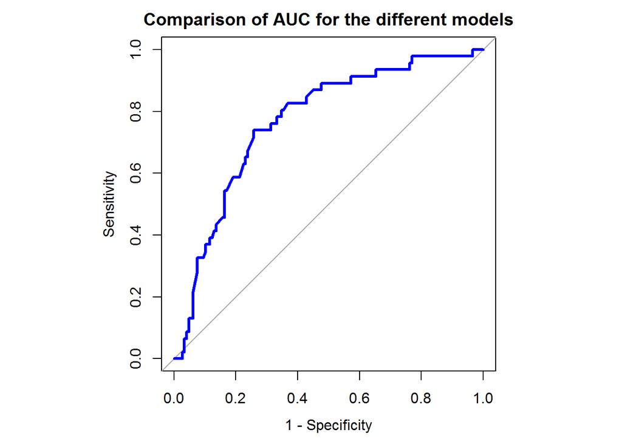

```r
## For improved graphs (remove dead space left & right)
par(pty="s")

## Area under the curve graph individual
plot.roc(roc(TBimputedtest$trtfailure, predictionforward), col = "blue", lwd = 3,
         main = "Comparison of AUC for the different models", xlab = "1 - Specificity", legacy.axes = TRUE)
```

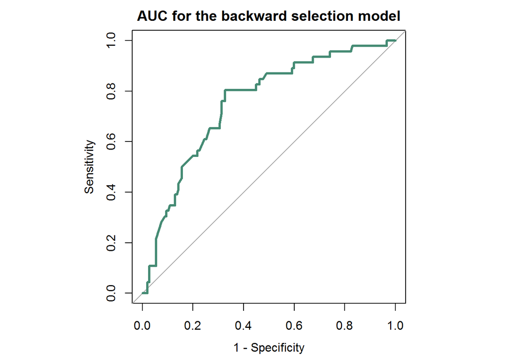

```r
plot.roc(roc(TBimputedtest$trtfailure, predictionbackward), col = "aquamarine4", lwd = 3,
         main = "AUC for the backward selection model", xlab = "1 - Specificity", legacy.axes = TRUE)
```

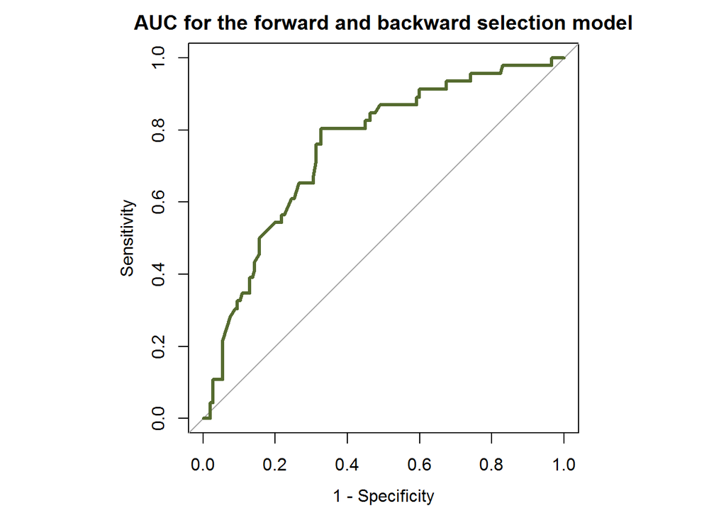

```r
plot.roc(roc(TBimputedtest$trtfailure, predictionboth), col = "darkolivegreen", lwd = 3,
         main = "AUC for the forward and backward selection model", xlab = "1 - Specificity", legacy.axes = TRUE)
```

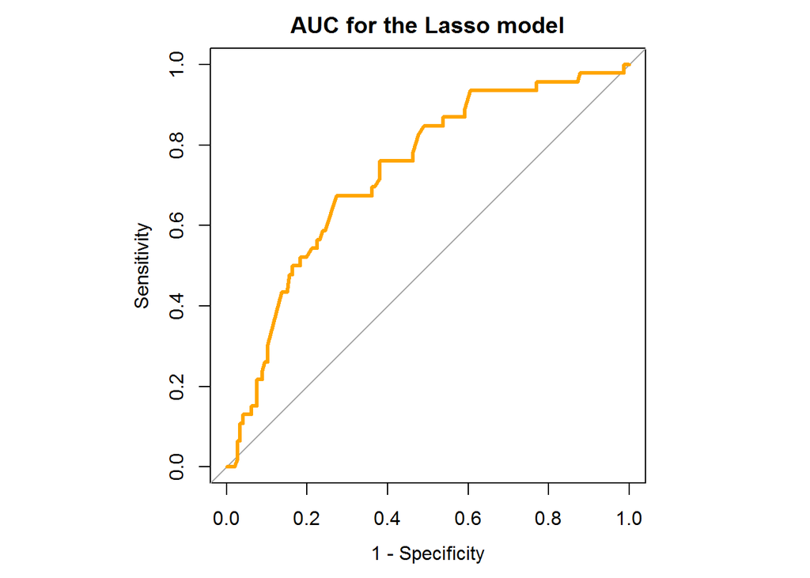

```r
plot.roc(roc(TBimputedtest$trtfailure, predictionlasso), col = "orange", lwd = 3,
         main = "AUC for the Lasso model", xlab = "1 - Specificity", legacy.axes = TRUE)
```

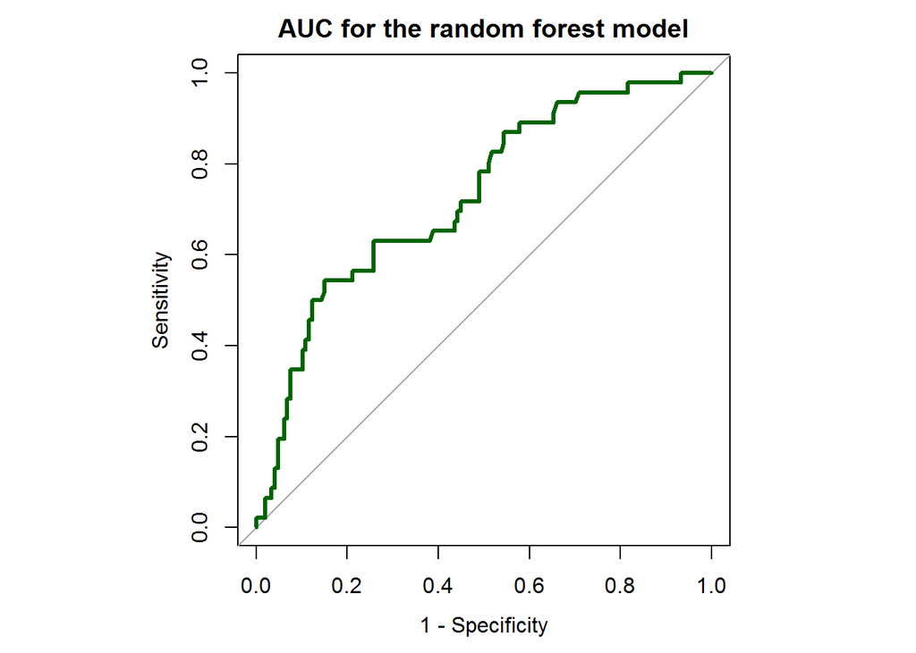

```r
plot.roc(roc(TBimputedtest$trtfailure, predictionforest), col = "darkgreen", lwd = 3,
         main = "AUC for the random forest model", xlab = "1 - Specificity", legacy.axes = TRUE)
```

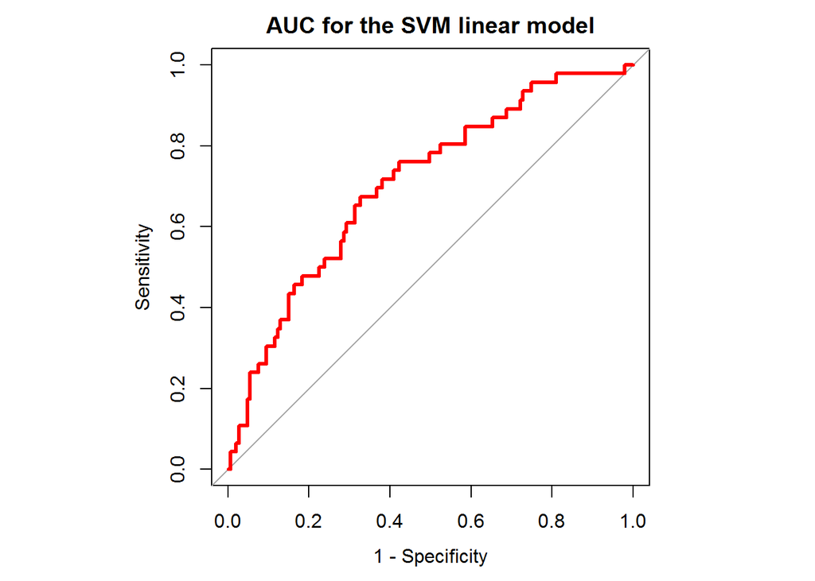

```r
plot.roc(roc(TBimputedtest$trtfailure, predictionsvmlinear), col = "red", lwd = 3,
         main = "AUC for the SVM linear model", xlab = "1 - Specificity", legacy.axes = TRUE)
```

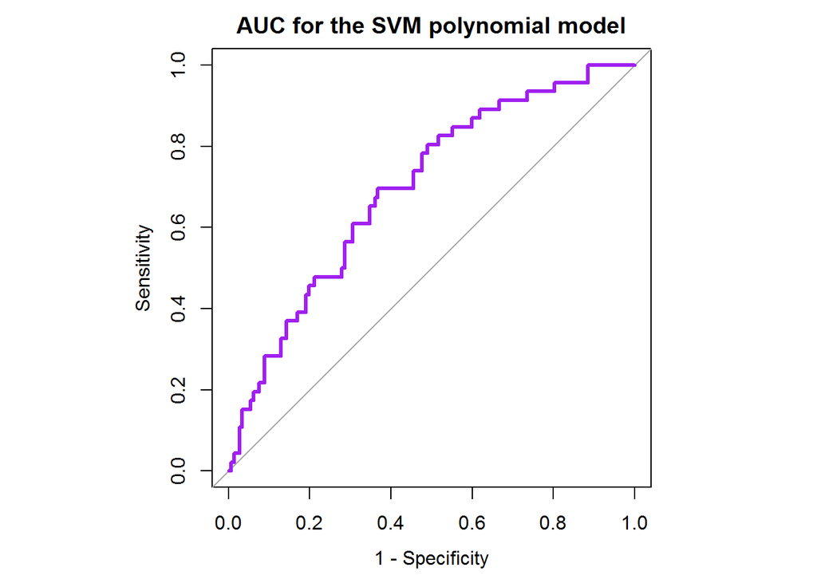

```r
plot.roc(roc(TBimputedtest$trtfailure, predictionsvmpolynomial), col = "purple", lwd = 3,
         main = "AUC for the SVM polynomial model", xlab = "1 - Specificity", legacy.axes = TRUE)
```

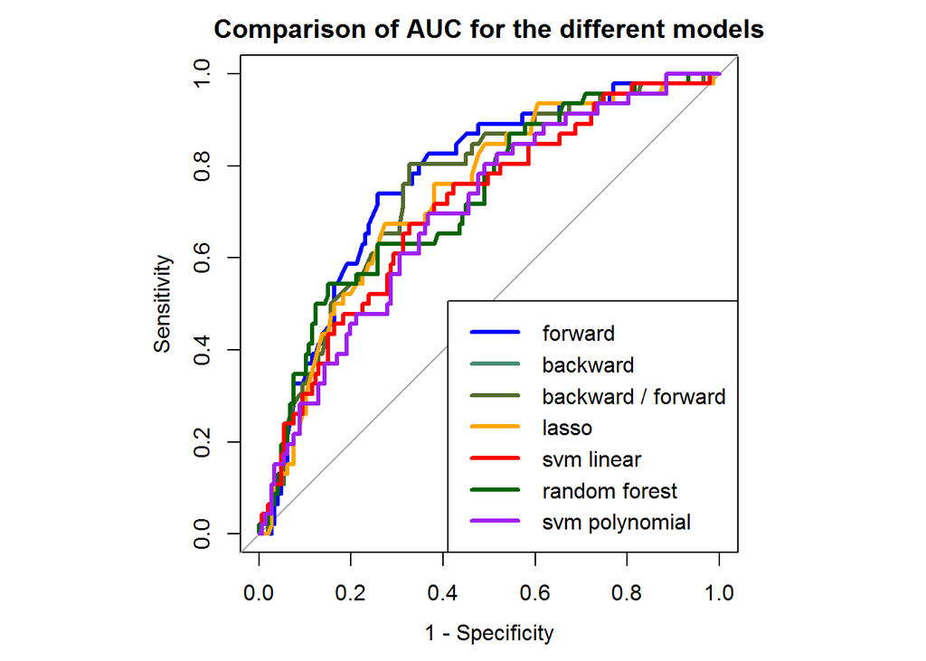

```r
par(pty="s")
plot.roc(roc(TBimputedtest$trtfailure, predictionforward), col = "blue", lwd = 3,
         main = "Comparison of AUC for the different models", xlab = "1 - Specificity", legacy.axes = TRUE)
plot.roc(roc(TBimputedtest$trtfailure, predictionbackward), add = TRUE,
         col = "aquamarine4", lwd = 3)
plot.roc(roc(TBimputedtest$trtfailure, predictionboth), add = TRUE,
         col = "darkolivegreen", lwd = 3)
plot.roc(roc(TBimputedtest$trtfailure, predictionlasso), add = TRUE,
         col = "orange", lwd = 3)
plot.roc(roc(TBimputedtest$trtfailure, predictionforest), add = TRUE,
         col = "darkgreen", lwd = 3)
plot.roc(roc(TBimputedtest$trtfailure, predictionsvmlinear), add = TRUE,
         col = "red", lwd = 3)
plot.roc(roc(TBimputedtest$trtfailure, predictionsvmpolynomial), add = TRUE,
         col = "purple", lwd = 3)
legend(x = "bottomright", legend = c("forward", "backward", "backward / forward",
                                     "lasso", "svm linear", "random forest",
                                     "svm polynomial"),
       lty = c(1, 1, 1, 1, 1, 1, 1), lwd = c(3, 3, 3, 3, 3, 3, 3),
       col = c("blue", "aquamarine4", "darkolivegreen", "orange", "red", "darkgreen", "purple"))
```

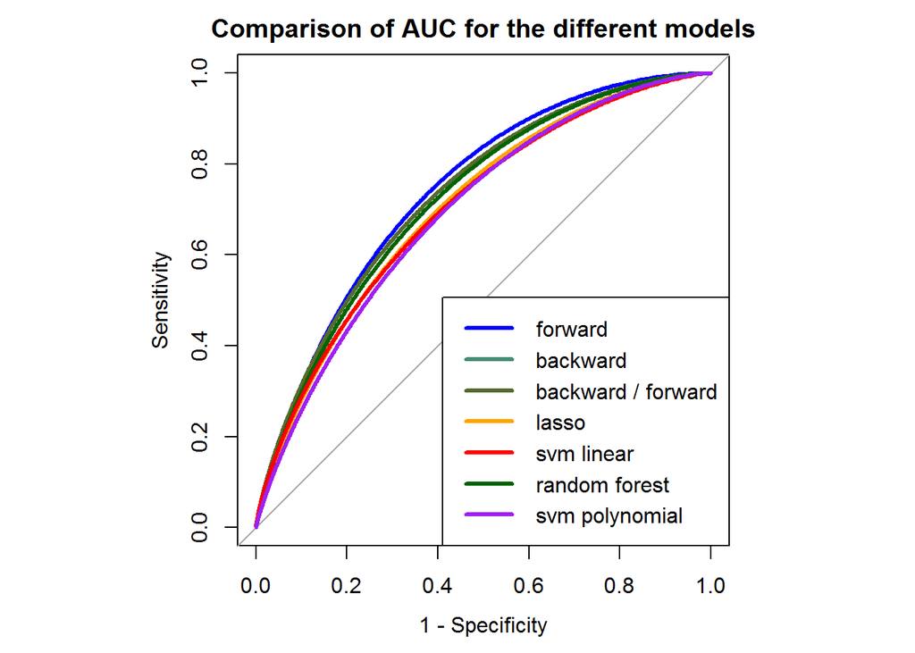

```r
## Area under the curve graph smoothed
par(pty="s")
plot.roc(smooth(roc(TBimputedtest$trtfailure, predictionforward)), col = "blue", lwd = 3,
         main = "Comparison of AUC for the different models", xlab = "1 - Specificity", legacy.axes = TRUE)
plot.roc(smooth(roc(TBimputedtest$trtfailure, predictionbackward)), add = TRUE,
         col = "aquamarine4", lwd = 3)
plot.roc(smooth(roc(TBimputedtest$trtfailure, predictionboth)), add = TRUE,
         col = "darkolivegreen", lwd = 3)
plot.roc(smooth(roc(TBimputedtest$trtfailure, predictionlasso)), add = TRUE,
         col = "orange", lwd = 3)
plot.roc(smooth(roc(TBimputedtest$trtfailure, predictionforest)), add = TRUE,
         col = "darkgreen", lwd = 3)
plot.roc(smooth(roc(TBimputedtest$trtfailure, predictionsvmlinear)), add = TRUE,
         col = "red", lwd = 3)
plot.roc(smooth(roc(TBimputedtest$trtfailure, predictionsvmpolynomial)), add = TRUE,
         col = "purple", lwd = 3)
legend(x = "bottomright", legend = c("forward", "backward", "backward / forward",
                                     "lasso", "svm linear", "random forest",
                                     "svm polynomial"),
       lty = c(1, 1, 1, 1, 1, 1, 1), lwd = c(3, 3, 3, 3, 3, 3, 3),
       col = c("blue", "aquamarine4", "darkolivegreen", "orange", "red", "darkgreen", "purple"))
```